# Problem Statement:

To Predict the Retention Potential levels of customers belonging to a retail company, using their past data of transactions with the company, interactions and value generated to the company.

# Business Perspective:

In almost any business the rate of customer retentions plays an important role in the growth of any company. The difference between companies that grow and those that don’t is customer churn. The more customers the company can keep and continue to sell to, the more likely it achieves the business goals.

Investment to acquire new customers far exceeds investment on retention. So, it is important for any company to focus on customers retention by identifying and contacting potential customers in different means.

# ROI:

1.Studies show that atleast 5% increase in customer retention can increase company revenue by 25-95%.

# Business Value:

1. Predicting the customers Retention Potential levels gives a clear perspective for the company regarding customers such that different strategies can be derived and used for handling customers of different type.
2. It helps company to concentrate more on customers who are highly retainable and communicate to them regarding offers or discounts.
3. Also helps in saving the time and human efforts from contacting the low potential customers who are not going to create any value to tha company.
4. Depending upon scale of customers a company has, regular prediction of customer retention potential levels and potential rate can help the company to cope up with the needs of the customer.

# Importing the required Libraries

```python
import pandas as pd
import numpy as np
import matplotlib.pyplot as plt
import seaborn as sns
import warnings
warnings.filterwarnings('ignore')
import datetime
from sklearn.preprocessing import StandardScaler
from sklearn.preprocessing import LabelEncoder
from sklearn.model_selection import train_test_split
from sklearn.ensemble import RandomForestClassifier
from sklearn.tree import DecisionTreeClassifier
from sklearn.model_selection import GridSearchCV
from sklearn.metrics import classification_report
from sklearn.metrics import plot_confusion_matrix,confusion_matrix
from imblearn.over_sampling import SMOTE
from lightgbm import LGBMClassifier
import tensorflow as tf
from tensorflow.keras import Sequential
from tensorflow.keras.layers import Dense, Input
from imblearn.over_sampling import RandomOverSampler
```

# Loading the required past data for analysis and prediction

```python
train=pd.read_excel('/content/drive/MyDrive/PHD/DataForPHD/TrainData/Train.xlsx')
custdata_train=pd.read_excel('/content/drive/MyDrive/PHD/DataForPHD/TrainData/Customerdata_Train.xlsx')
emaildata_train=pd.read_excel('/content/drive/MyDrive/PHD/DataForPHD/TrainData/Emaildata_Train.xlsx')
transactionsdata_train=pd.read_excel('/content/drive/MyDrive/PHD/DataForPHD/TrainData/transactionsdata_Train.xlsx')

test=pd.read_excel('/content/drive/MyDrive/PHD/DataForPHD/TestData/Test.xlsx')
custdata_test=pd.read_excel('/content/drive/MyDrive/PHD/DataForPHD/TestData/Customerdata_Test.xlsx')
emaildata_test=pd.read_excel('/content/drive/MyDrive/PHD/DataForPHD/TestData/Emaildata_Test.xlsx')
transactionsdata_test=pd.read_excel('/content/drive/MyDrive/PHD/DataForPHD/TestData/transactionsdata_Test.xlsx')
```

We have the data in the form of four datasets:

1. Customer Demographics data.
2. Transactions data.
3. Email interaction data.
4. The retention potential level for a particular customer.

# 1 Basic Analysis

```python
def inspect_data(data):
    return pd.DataFrame({"Data Type":data.dtypes,"No of Levels":data.apply(lambda x: x.nunique(),axis=0),"% of Unique Levels":data.apply(lambda x: 100*x.nunique()/len(x),axis=0), "Levels":data.apply(lambda x: str(x.unique()),axis=0)}).sort_values("% of Unique Levels", ascending=False)
```

## 1.1 Customer Data Analysis

```python
custdata_train.describe(include='all')
```

|  | CustomerID | City | DateOfRegistration | OnlineCommunication | AutomaticRefill | DoorstepDelivery | PreferredDeliveryDay |
| --- | --- | --- | --- | --- | --- | --- | --- |
| count | 23820 | 23820 | 23820 | 23820.000000 | 23820.000000 | 23820.000000 | 23820 |
| unique | 23820 | 4 | 2673 | NaN | NaN | NaN | 7 |
| top | C14305 | CITY4 | 2012-08-28 00:00:00 | NaN | NaN | NaN | Tuesday |
| freq | 1 | 9143 | 356 | NaN | NaN | NaN | 5343 |
| first | NaN | NaN | 2008-06-17 00:00:00 | NaN | NaN | NaN | NaN |
| last | NaN | NaN | 2018-01-17 00:00:00 | NaN | NaN | NaN | NaN |
| mean | NaN | NaN | NaN | 0.660411 | 0.094710 | 0.037615 | NaN |
| std | NaN | NaN | NaN | 0.473580 | 0.292821 | 0.190268 | NaN |
| min | NaN | NaN | NaN | 0.000000 | 0.000000 | 0.000000 | NaN |
| 25% | NaN | NaN | NaN | 0.000000 | 0.000000 | 0.000000 | NaN |
| 50% | NaN | NaN | NaN | 1.000000 | 0.000000 | 0.000000 | NaN |
| 75% | NaN | NaN | NaN | 1.000000 | 0.000000 | 0.000000 | NaN |
| max | NaN | NaN | NaN | 1.000000 | 1.000000 | 1.000000 | NaN |

```python
inspect_data(custdata_train)
```

|  | Data Type | No of Levels | % of Unique Levels | Levels |
| --- | --- | --- | --- | --- |
| CustomerID | object | 23820 | 100.000000 | ['C16368' 'C20345' 'C17683' ... 'C40967' 'C361... |
| DateOfRegistration | datetime64[ns] | 2673 | 11.221662 | ['2012-09-28T00:00:00.000000000' '2010-12-19T0... |
| PreferredDeliveryDay | object | 7 | 0.029387 | ['Monday' 'Friday' 'Wednesday' 'Tuesday' 'Thur... |
| City | object | 4 | 0.016793 | ['CITY2' 'CITY4' 'CITY3' 'CITY1'] |
| OnlineCommunication | int64 | 2 | 0.008396 | [0 1] |
| AutomaticRefill | int64 | 2 | 0.008396 | [0 1] |
| DoorstepDelivery | int64 | 2 | 0.008396 | [0 1] |

```python
inspect_data(custdata_test)
```

|  | Data Type | No of Levels | % of Unique Levels | Levels |
| --- | --- | --- | --- | --- |
| CustomerID | object | 5955 | 100.000000 | ['C17838' 'C12403' 'C19041' ... 'C38741' 'C204... |
| DateOfRegistration | datetime64[ns] | 1631 | 27.388749 | ['2010-10-22T00:00:00.000000000' '2008-11-17T0... |
| PreferredDeliveryDay | object | 7 | 0.117548 | ['Thursday' 'Wednesday' 'Friday' 'Monday' 'Tue... |
| City | object | 4 | 0.067170 | ['CITY4' 'CITY2' 'CITY3' 'CITY1'] |
| OnlineCommunication | int64 | 2 | 0.033585 | [0 1] |
| AutomaticRefill | int64 | 2 | 0.033585 | [0 1] |
| DoorstepDelivery | int64 | 2 | 0.033585 | [0 1] |

```python
min(custdata_train.DateOfRegistration),max(custdata_train.DateOfRegistration)
```

```
(Timestamp('2008-06-17 00:00:00'), Timestamp('2018-01-17 00:00:00'))
```

```python
min(custdata_test.DateOfRegistration),max(custdata_test.DateOfRegistration)
```

```
(Timestamp('2008-07-17 00:00:00'), Timestamp('2018-01-17 00:00:00'))
```

## Combining Customer data with the target variable.

```python
custdata_train_y=pd.merge(custdata_train,train,on='CustomerID',how='left')
```

```python
custdata_train_y.RetentionPotential.value_counts()
```

```
Low       19185
High       3756
Medium      879
Name: RetentionPotential, dtype: int64
```

The above results shows that we have large number of customers who are of low RetentionPotential, which is followed by High and Medium level potential customers.

## 1.2 Email Data Analysis

```python
emaildata_train
```

|  | CustomerID | DateOfemail | EmailType | timestamp | MailOpened | MailClicked |
| --- | --- | --- | --- | --- | --- | --- |
| 0 | C16368 | 2012-09-28 | WelcomeEmail | 15:56:50 | yes | NotApplicable |
| 1 | C20345 | 2010-12-19 | WelcomeEmail | 15:10:30 | yes | NotApplicable |
| 2 | C17683 | 2010-10-03 | WelcomeEmail | 17:12:24 | yes | NotApplicable |
| 3 | C18647 | 2010-11-27 | WelcomeEmail | 16:59:02 | yes | NotApplicable |
| 4 | C36692 | 2009-12-04 | WelcomeEmail | 17:27:22 | yes | NotApplicable |
| ... | ... | ... | ... | ... | ... | ... |
| 517667 | C36140 | 2018-01-18 | CustomizedEmail | 14:04:44 | yes | yes |
| 517668 | C36140 | 2018-01-21 | CustomizedEmail | 16:17:16 | no | no |
| 517669 | C36140 | 2018-01-20 | CustomizedEmail | 12:17:34 | yes | yes |
| 517670 | C36140 | 2018-01-20 | CustomizedEmail | 16:31:18 | yes | no |
| 517671 | C36140 | 2018-01-21 | CustomizedEmail | 14:23:16 | yes | yes |

517672 rows × 6 columns

```python
emaildata_train.shape
```

```
(517672, 6)
```

```python
inspect_data(emaildata_train)
```

|  | Data Type | No of Levels | % of Unique Levels | Levels |
| --- | --- | --- | --- | --- |
| CustomerID | object | 23820 | 4.601369 | ['C16368' 'C20345' 'C17683' ... 'C40967' 'C361... |
| timestamp | object | 14369 | 2.775696 | ['15:56:50' '15:10:30' '17:12:24' ... '16:09:1... |
| DateOfemail | object | 3382 | 0.653309 | ['2012-09-28' '2010-12-19' '2010-10-03' ... '2... |
| MailClicked | object | 3 | 0.000580 | ['NotApplicable' 'no' 'yes'] |
| EmailType | object | 2 | 0.000386 | ['WelcomeEmail' 'CustomizedEmail'] |
| MailOpened | object | 2 | 0.000386 | ['yes' 'no'] |

From the above result every thing is intuitive except the NotApplicable option for MailClicked attribute.

Checking more on Mailclicked attribute.

```python
emaildata_train.loc[emaildata_train.MailClicked=='NotApplicable','EmailType'].value_counts()
```

```
WelcomeEmail    23820
Name: EmailType, dtype: int64
```

It is clear that, there is an welcome email sent for every customer and only it has MailClicked as 'NotApplicable'.

```python
max(emaildata_train.DateOfemail),min(emaildata_train.DateOfemail)
```

```
('2018-01-21', '2008-06-17')
```

## **Insights:**

The Email data contains 517672 emails sent to 23820(between 17/06/2008 and 21/01/2018) customers at different times with various details about the particualar email like below.

a. Date and Time of email.

b. Type: Welcome email(sent to customer probably when he registers) and Customized Email.

c. Mail Opened: Whether the mail is opened or not.

d. Mail Clicked: If opened, did the customer clicked on any link or something in the email.

Note: another values 'Not applicable' is available which indicates the welcome email type.

```python
inspect_data(emaildata_test)
```

|  | Data Type | No of Levels | % of Unique Levels | Levels |
| --- | --- | --- | --- | --- |
| timestamp | object | 14366 | 11.130049 | ['16:59:02' '12:46:56' '14:35:22' ... '14:51:3... |
| CustomerID | object | 5955 | 4.613632 | ['C17838' 'C12403' 'C19041' ... 'C38741' 'C204... |
| DateOfemail | object | 3149 | 2.439686 | ['2010-10-22' '2008-11-17' '2011-01-24' ... '2... |
| MailClicked | object | 3 | 0.002324 | ['NotApplicable' 'no' 'yes'] |
| EmailType | object | 2 | 0.001549 | ['WelcomeEmail' 'CustomizedEmail'] |
| MailOpened | object | 2 | 0.001549 | ['yes' 'no'] |

All the details are same as the train data.

## 1.3 Transactions data

```python
transactionsdata_train
```

|  | CustomerID | DateOfOrder | timestamp | OrderQuantity |
| --- | --- | --- | --- | --- |
| 0 | C16368 | 2013-08-11 | 15:17:52 | 15 |
| 1 | C20345 | 2011-04-01 | 19:50:00 | 92 |
| 2 | C20345 | 2012-06-29 | 15:11:56 | 95 |
| 3 | C20345 | 2012-09-22 | 20:49:10 | 74 |
| 4 | C20345 | 2011-08-23 | 11:50:26 | 81 |
| ... | ... | ... | ... | ... |
| 104750 | C12197 | 2018-01-17 | 14:35:40 | 56 |
| 104751 | C40967 | 2018-01-17 | 17:15:20 | 35 |
| 104752 | C36140 | 2018-01-17 | 13:12:54 | 47 |
| 104753 | C36140 | 2018-01-21 | 21:12:52 | 53 |
| 104754 | C42003 | 2018-01-17 | 16:34:46 | 41 |

104755 rows × 4 columns

```python
inspect_data(transactionsdata_train)
```

|  | Data Type | No of Levels | % of Unique Levels | Levels |
| --- | --- | --- | --- | --- |
| CustomerID | object | 23820 | 22.738771 | ['C16368' 'C20345' 'C17683' ... 'C40967' 'C361... |
| timestamp | object | 21399 | 20.427665 | ['15:17:52' '19:50:00' '15:11:56' ... '13:56:4... |
| DateOfOrder | object | 3151 | 3.007971 | ['2013-08-11' '2011-04-01' '2012-06-29' ... '2... |
| OrderQuantity | int64 | 451 | 0.430528 | [ 15 92 95 74 81 78 83 86 85 ... |

Train Data contains 104755 listed transactions of 23820 customers with date and Time of the Transactions and also the total order a customer made during that transaction.

```python
inspect_data(transactionsdata_test)
```

|  | Data Type | No of Levels | % of Unique Levels | Levels |
| --- | --- | --- | --- | --- |
| timestamp | object | 15326 | 57.254931 | ['17:41:08' '15:58:02' '20:13:48' ... '10:07:4... |
| CustomerID | object | 5955 | 22.246712 | ['C17838' 'C12403' 'C19041' ... 'C38741' 'C204... |
| DateOfOrder | object | 2771 | 10.351913 | ['2011-03-28' '2010-10-12' '2010-11-27' ... '2... |
| OrderQuantity | int64 | 372 | 1.389719 | [ 55 174 171 166 179 163 160 164 175 159 176 1... |

There are different details of the customers with contacts and transactions, we need to combine all this data in a way that would be effective for the algorithm to learn for predicting the RetentionPotential level of a customer.

Before that we need to understand more on the data.

# 2 Deep dive in to the data using Visualization and Feature Engineering.

## 2.1 Customer Data

```python
custdata_train_y
```

|  | CustomerID | City | DateOfRegistration | OnlineCommunication | AutomaticRefill | DoorstepDelivery | PreferredDeliveryDay | RetentionPotential |
| --- | --- | --- | --- | --- | --- | --- | --- | --- |
| 0 | C16368 | CITY2 | 2012-09-28 | 0 | 0 | 0 | Monday | High |
| 1 | C20345 | CITY2 | 2010-12-19 | 1 | 1 | 1 | Friday | Low |
| 2 | C17683 | CITY2 | 2010-10-03 | 0 | 0 | 0 | Wednesday | Medium |
| 3 | C18647 | CITY4 | 2010-11-27 | 0 | 0 | 0 | Monday | Low |
| 4 | C36692 | CITY2 | 2009-12-04 | 1 | 1 | 0 | Friday | Low |
| ... | ... | ... | ... | ... | ... | ... | ... | ... |
| 23815 | C23511 | CITY2 | 2018-01-17 | 1 | 1 | 0 | Friday | Low |
| 23816 | C12197 | CITY3 | 2018-01-17 | 1 | 0 | 1 | Friday | Low |
| 23817 | C40967 | CITY3 | 2018-01-17 | 1 | 0 | 0 | Saturday | Low |
| 23818 | C36140 | CITY3 | 2018-01-17 | 1 | 1 | 0 | Saturday | Low |
| 23819 | C42003 | CITY4 | 2018-01-17 | 1 | 0 | 0 | Friday | Low |

23820 rows × 8 columns

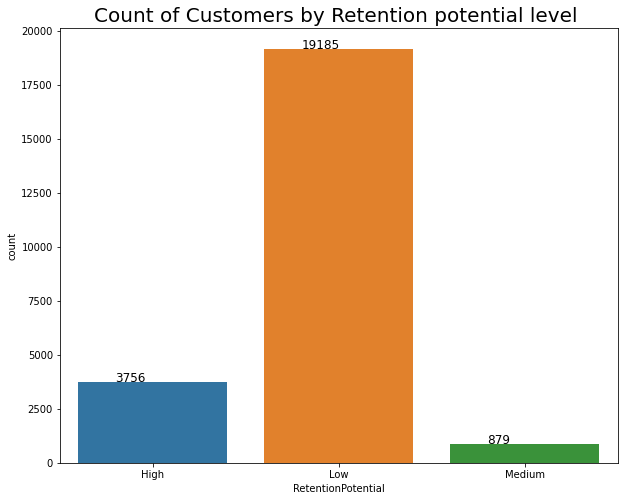

```python
plt.figure(figsize=(10,8))
ax=sns.countplot(custdata_train_y.RetentionPotential)
plt.title("Count of Customers by Retention potential level ",fontsize=20,fontweight=10)
for p in ax.patches:
  ax.annotate(f'\n{p.get_height()}', (p.get_x()+0.2, p.get_height()), ha='left', va='baseline', color='black', size=12)

plt.show()
```

### 2.1.1 Checking if City would have any influence on Retention Potential

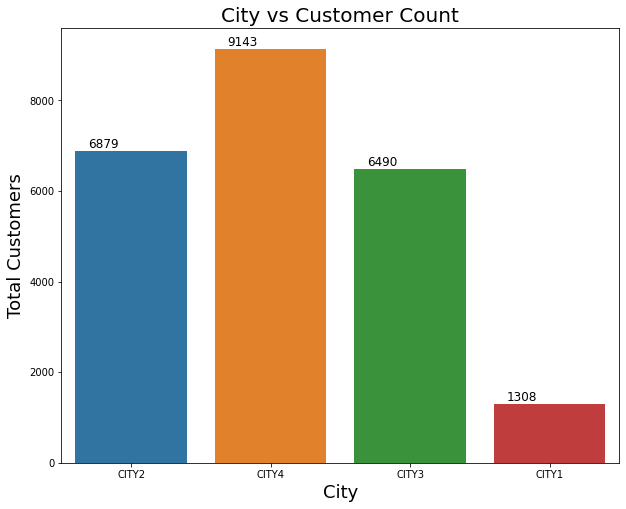

```python
plt.figure(figsize=(10,8))
ax=sns.countplot(custdata_train_y.City)
plt.xlabel('City',fontsize=18)
plt.ylabel('Total Customers',fontsize=18)
plt.title('City vs Customer Count',fontsize=20)
for p in ax.patches:
  ax.annotate(f'\n{p.get_height()}', (p.get_x()+0.2, p.get_height()), ha='center', va='bottom', color='black', size=12)
plt.show()
plt.show()
```

We have less customers from City1 and more customers from City4.

Let's see how the distribution of different levels are in different cities

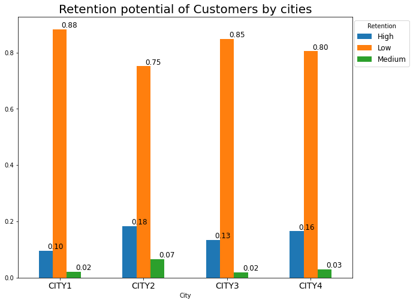

```python
ax=pd.crosstab(custdata_train_y.City,custdata_train_y.RetentionPotential,normalize='index').plot(kind='bar',figsize=(10,8))
plt.title("Retention potential of Customers by cities",fontsize=20,fontweight=10)
plt.xticks(fontsize=14, rotation='horizontal')
plt.legend(title='Retention',bbox_to_anchor=(1.18, 1),prop={'size': 12})
for p in ax.patches:
  ax.annotate(f'\n{p.get_height():3.2f}', (p.get_x()+0.2, p.get_height()), ha='center', va='bottom', color='black', size=12)
plt.show()
```

### 2.1.2 Retential Potential vs Preffered Delivery day

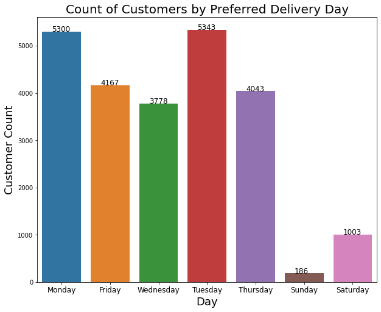

```python
plt.figure(figsize=(10,8))
ax=sns.countplot(custdata_train_y.PreferredDeliveryDay)
plt.title("Count of Customers by Preferred Delivery Day",fontsize=20,fontweight=10)
plt.xlabel('Day',fontsize=18)
plt.ylabel('Customer Count',fontsize=18)
plt.xticks(fontsize=12)
for p in ax.patches:
  ax.annotate(f'\n{p.get_height()}', (p.get_x()+0.2, p.get_height()), ha='left', va='baseline', color='black', size=12)

plt.show()
```

Customers with Weekends as Preferred Delivery Day are very less. With Monday and Tuesday are more.

I assume most of the customers are working professionals who may prefer to go out on weekends with their family and on weekdays someone would there in home to take the order.

NOTE: Just an assumption.

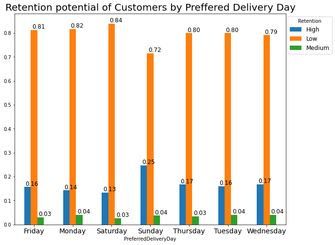

```python
ax=pd.crosstab(custdata_train_y.PreferredDeliveryDay,custdata_train_y.RetentionPotential,normalize='index').plot(kind='bar',figsize=(10,8))
plt.title("Retention potential of Customers by Preffered Delivery Day",fontsize=20,fontweight=10)
plt.xticks(fontsize=14, rotation='horizontal')
plt.legend(title='Retention',bbox_to_anchor=(1.18, 1),prop={'size': 12})
for p in ax.patches:
  ax.annotate(f'\n{p.get_height():3.2f}', (p.get_x()+0.2, p.get_height()), ha='center', va='bottom', color='black', size=12)
plt.show()
```

It is clear that there is no pattern here, all values are approximately same and therefore the preferred delivery also day may not give us a clear edge in predicting Potential level.

### 2.1.3 Online communication vs Retention Potential

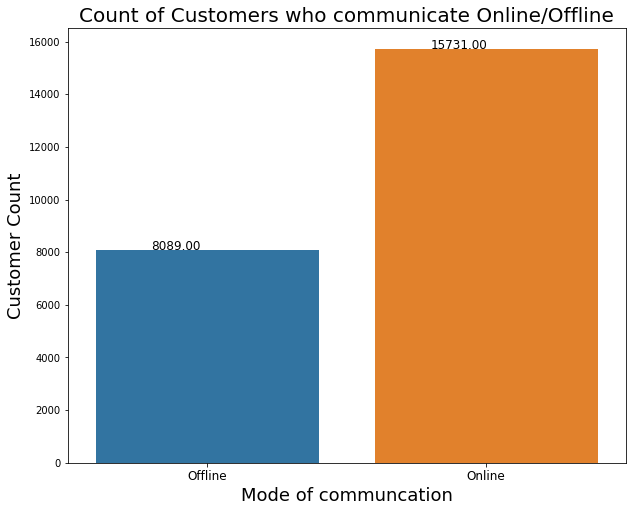

```python
plt.figure(figsize=(10,8))
ax=sns.countplot(custdata_train_y.OnlineCommunication)
plt.title("Count of Customers who communicate Online/Offline",fontsize=20,fontweight=10)
plt.xlabel('Mode of communcation',fontsize=18)
plt.xticks([0,1],['Offline','Online'],fontsize=30)
plt.ylabel('Customer Count',fontsize=18)
plt.xticks(fontsize=12)
for p in ax.patches:
  ax.annotate(f'\n{p.get_height():3.2f}', (p.get_x()+0.2, p.get_height()), ha='left', va='baseline', color='black', size=12)
plt.show()
```

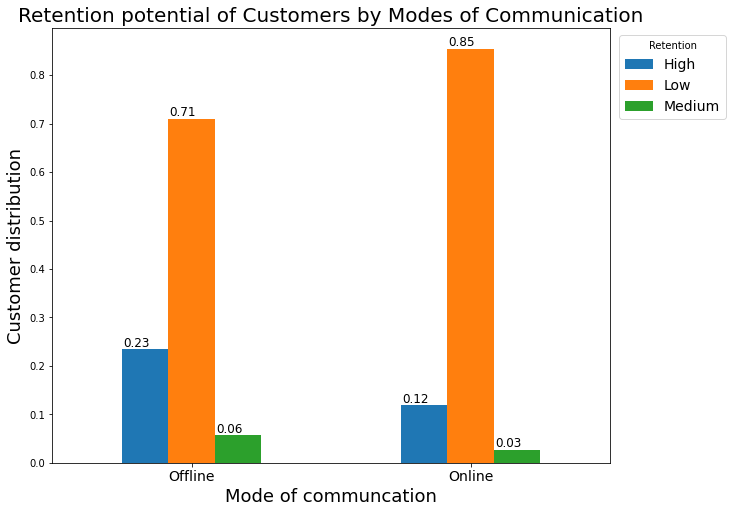

```python
ax=pd.crosstab(custdata_train_y.OnlineCommunication,custdata_train_y.RetentionPotential,normalize='index').plot(kind='bar',figsize=(10,8))
plt.title("Retention potential of Customers by Modes of Communication",fontsize=20,fontweight=10)
plt.xticks([0,1],['Offline','Online'],fontsize=14, rotation='horizontal')
plt.xlabel('Mode of communcation',fontsize=18)
plt.ylabel('Customer distribution',fontsize=18)
plt.legend(title='Retention',bbox_to_anchor=(1.22, 1),prop={'size': 14})
for p in ax.patches:
  ax.annotate(f'\n{p.get_height():3.2f}', (p.get_x()+0.1, p.get_height()), ha='right', va='bottom', color='black', size=12)
plt.show()
```

Out of people who communicate offline we have Low potential user percentage less when compared to customers who communicate online. In the same way we have percentage of users who are high potential more in offline customers.

So, i think Mode of communication plays a key role in predicting the Potential level.

### 2.1.4 Retention Potential vs AutoRefill

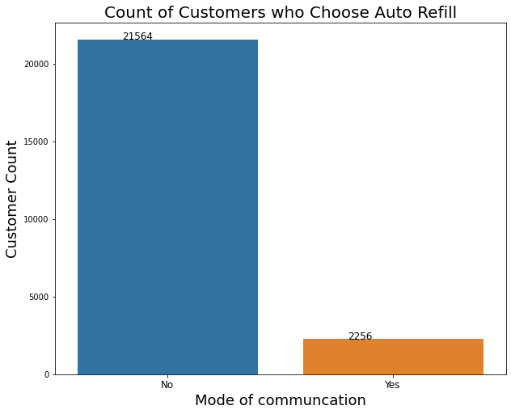

```python
plt.figure(figsize=(10,8))
ax=sns.countplot(custdata_train_y.AutomaticRefill)
plt.title("Count of Customers who Choose Auto Refill",fontsize=20,fontweight=10)
plt.xlabel('Mode of communcation',fontsize=18)
plt.xticks([0,1],['No','Yes'],fontsize=30)
plt.ylabel('Customer Count',fontsize=18)
plt.xticks(fontsize=12)
for p in ax.patches:
  ax.annotate(f'\n{p.get_height()}', (p.get_x()+0.2, p.get_height()), ha='left', va='baseline', color='black', size=12)
plt.show()
```

Customers preferring Auto Refill are very less.

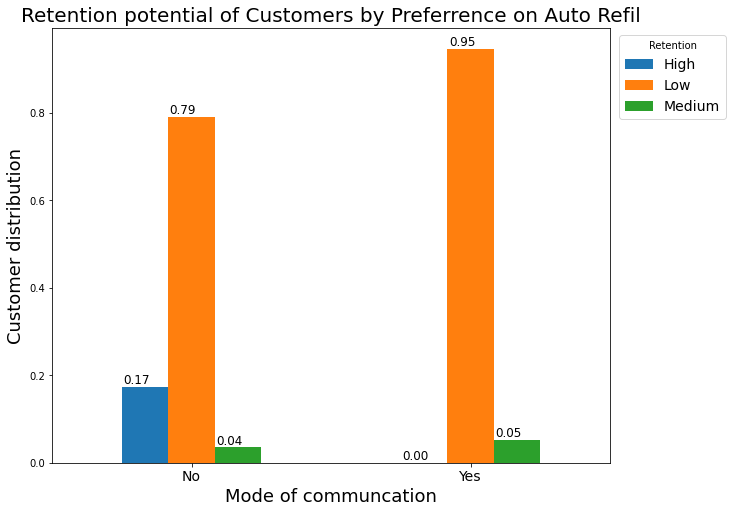

```python
ax=pd.crosstab(custdata_train_y.AutomaticRefill,custdata_train_y.RetentionPotential,normalize='index').plot(kind='bar',figsize=(10,8))
plt.title("Retention potential of Customers by Preferrence on Auto Refil",fontsize=20,fontweight=10)
plt.xticks([0,1],['No','Yes'],fontsize=14, rotation='horizontal')
plt.xlabel('Mode of communcation',fontsize=18)
plt.ylabel('Customer distribution',fontsize=18)
plt.legend(title='Retention',bbox_to_anchor=(1.22, 1),prop={'size': 14})
for p in ax.patches:
  ax.annotate(f'\n{p.get_height():3.2f}', (p.get_x()+0.1, p.get_height()), ha='right', va='bottom', color='black', size=12)
plt.show()
```

We have no high potential customers who prefer auto refill.

## 2.2 Transaction Data

```python
transactionsdata_train
```

|  | CustomerID | DateOfOrder | timestamp | OrderQuantity |
| --- | --- | --- | --- | --- |
| 0 | C16368 | 2013-08-11 | 15:17:52 | 15 |
| 1 | C20345 | 2011-04-01 | 19:50:00 | 92 |
| 2 | C20345 | 2012-06-29 | 15:11:56 | 95 |
| 3 | C20345 | 2012-09-22 | 20:49:10 | 74 |
| 4 | C20345 | 2011-08-23 | 11:50:26 | 81 |
| ... | ... | ... | ... | ... |
| 104750 | C12197 | 2018-01-17 | 14:35:40 | 56 |
| 104751 | C40967 | 2018-01-17 | 17:15:20 | 35 |
| 104752 | C36140 | 2018-01-17 | 13:12:54 | 47 |
| 104753 | C36140 | 2018-01-21 | 21:12:52 | 53 |
| 104754 | C42003 | 2018-01-17 | 16:34:46 | 41 |

104755 rows × 4 columns

```python
transactionsdata_train.DateOfOrder=pd.to_datetime(transactionsdata_train.DateOfOrder)
transactionsdata_test.DateOfOrder=pd.to_datetime(transactionsdata_test.DateOfOrder)
transactionsdata_train['Year']= pd. DatetimeIndex(transactionsdata_train.DateOfOrder).year
transactionsdata_test['Year']=pd. DatetimeIndex(transactionsdata_test.DateOfOrder).year
yearlyorders_train=pd.DataFrame(transactionsdata_train.groupby('Year').sum()).reset_index()
yearlyorders_test=pd.DataFrame(transactionsdata_test.groupby('Year').sum()).reset_index()
```

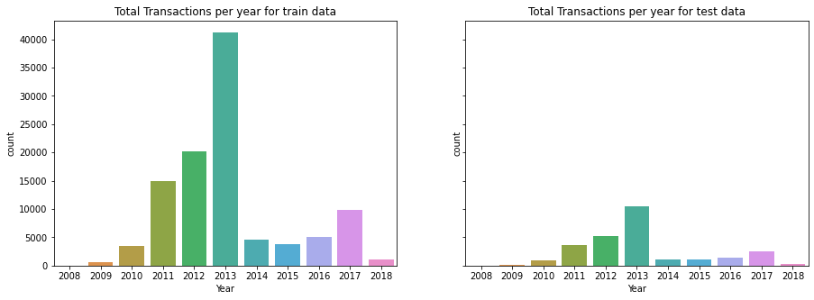

```python
fig, axes = plt.subplots(1, 2, figsize=(15, 5), sharey=True)
sns.countplot(transactionsdata_train['Year'],ax=axes[0])
axes[0].set_title('Total Transactions per year for train data')
sns.countplot(transactionsdata_test['Year'],ax=axes[1])
axes[1].set_title('Total Transactions per year for test data')
```

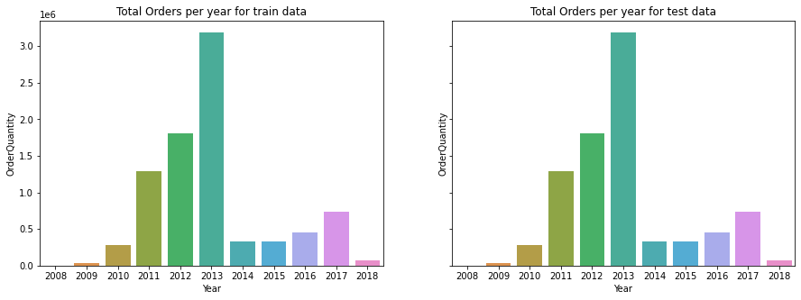

```python
fig, axes = plt.subplots(1, 2, figsize=(15, 5), sharey=True)
sns.barplot(yearlyorders_train.Year,yearlyorders_train.OrderQuantity,ax=axes[0])
axes[0].set_title('Total Orders per year for train data')
sns.barplot(yearlyorders_test.Year,yearlyorders_train.OrderQuantity,ax=axes[1])
axes[1].set_title('Total Orders per year for test data')
plt.show()
```

The company has increase in transactions and revenue untill the year 2013 and after that it experienced drastic decrease in the transactions

### 2.2.1 Calculating the total transactions every customer made.

```python
transactions_counts_train=pd.DataFrame(transactionsdata_train.groupby('CustomerID')['DateOfOrder'].nunique()).reset_index()
transactions_counts_train.rename(columns={'DateOfOrder':'TotalTransactions'},inplace=True)
transactions_counts_train

transactions_counts_test=pd.DataFrame(transactionsdata_test.groupby('CustomerID')['DateOfOrder'].nunique()).reset_index()
transactions_counts_test.rename(columns={'DateOfOrder':'TotalTransactions'},inplace=True)
transactions_counts_test
```

|  | CustomerID | TotalTransactions |
| --- | --- | --- |
| 0 | C12121 | 1 |
| 1 | C12132 | 1 |
| 2 | C12134 | 1 |
| 3 | C12135 | 1 |
| 4 | C12136 | 1 |
| ... | ... | ... |
| 5950 | C42153 | 5 |
| 5951 | C42155 | 1 |
| 5952 | C42157 | 1 |
| 5953 | C42167 | 6 |
| 5954 | C42190 | 1 |

5955 rows × 2 columns

```python
min(transactions_counts_train.TotalTransactions),max(transactions_counts_train.TotalTransactions)
```

```
(1, 257)
```

The minimum transactions a customer made was 1 and maximum transactions are 257.

```python
min(transactions_counts_test.TotalTransactions),max(transactions_counts_test.TotalTransactions)
```

```
(1, 185)
```

### 2.2.2 Calculating the total orders made by the customer

```python
order_count_train=pd.DataFrame(transactionsdata_train.groupby('CustomerID')['OrderQuantity'].sum()).reset_index()
order_count_train.rename(columns={'OrderQuantity':'TotalOrderQuantity'},inplace=True)
order_count_train

order_count_test=pd.DataFrame(transactionsdata_test.groupby('CustomerID')['OrderQuantity'].sum()).reset_index()
order_count_test.rename(columns={'OrderQuantity':'TotalOrderQuantity'},inplace=True)
order_count_test
```

|  | CustomerID | TotalOrderQuantity |
| --- | --- | --- |
| 0 | C12121 | 52 |
| 1 | C12132 | 40 |
| 2 | C12134 | 40 |
| 3 | C12135 | 41 |
| 4 | C12136 | 79 |
| ... | ... | ... |
| 5950 | C42153 | 379 |
| 5951 | C42155 | 41 |
| 5952 | C42157 | 41 |
| 5953 | C42167 | 502 |
| 5954 | C42190 | 40 |

5955 rows × 2 columns

```python
order_count_train
```

|  | CustomerID | TotalOrderQuantity |
| --- | --- | --- |
| 0 | C12116 | 115 |
| 1 | C12117 | 41 |
| 2 | C12118 | 41 |
| 3 | C12119 | 52 |
| 4 | C12120 | 31 |
| ... | ... | ... |
| 23815 | C42185 | 1340 |
| 23816 | C42186 | 46 |
| 23817 | C42187 | 41 |
| 23818 | C42188 | 51 |
| 23819 | C42189 | 180 |

23820 rows × 2 columns

```python
min(order_count_train.TotalOrderQuantity),max(order_count_train.TotalOrderQuantity)
```

```
(0, 51429)
```

```python
min(order_count_test.TotalOrderQuantity),max(order_count_test.TotalOrderQuantity)
```

```
(1, 57960)
```

We have min order as 0 and max order as 51429 for train data.

Checking more on 0 orders customer.

```python
order_count_train[order_count_train.TotalOrderQuantity<1]
```

|  | CustomerID | TotalOrderQuantity |
| --- | --- | --- |
| 2932 | C15837 | 0 |

checking the customer transactions.

```python
transactionsdata_train[transactionsdata_train.CustomerID=='C15837']
```

|  | CustomerID | DateOfOrder | timestamp | OrderQuantity |
| --- | --- | --- | --- | --- |
| 64155 | C15837 | 2010-08-04 | 11:54:48 | 0 |
| 64156 | C15837 | 2010-08-13 | 11:01:08 | 0 |
| 64157 | C15837 | 2010-08-12 | 12:23:18 | 0 |
| 64158 | C15837 | 2010-09-27 | 18:10:54 | 0 |
| 64159 | C15837 | 2010-08-17 | 17:49:00 | 0 |
| 64160 | C15837 | 2010-09-17 | 19:16:56 | 0 |
| 64161 | C15837 | 2010-08-11 | 19:36:24 | 0 |
| 64162 | C15837 | 2010-08-26 | 18:34:46 | 0 |
| 64163 | C15837 | 2010-08-14 | 12:07:30 | 0 |
| 64164 | C15837 | 2010-08-06 | 13:22:34 | 0 |
| 64165 | C15837 | 2010-09-10 | 21:11:16 | 0 |
| 64166 | C15837 | 2010-10-06 | 16:17:24 | 0 |

Surprisingly, the particular customer has 12 transaction records whose Order quantity was 0 everytime.

### 2.2.3 Combining all the transaction dates a customer

```python
transactionsdata_train.sort_values('DateOfOrder',inplace=True)
transactionsdata_test.sort_values('DateOfOrder',inplace=True)
```

```python
transactionsdata_train1=pd.DataFrame(transactionsdata_train.groupby('CustomerID')['DateOfOrder'].unique()).reset_index()
transactionsdata_test1=pd.DataFrame(transactionsdata_test.groupby('CustomerID')['DateOfOrder'].unique()).reset_index()

transactionsdata_train1
```

|  | CustomerID | DateOfOrder |
| --- | --- | --- |
| 0 | C12116 | [2013-10-03, 2013-10-08, 2013-10-10] |
| 1 | C12117 | [2013-12-05] |
| 2 | C12118 | [2013-09-10] |
| 3 | C12119 | [2013-10-22] |
| 4 | C12120 | [2014-01-10] |
| ... | ... | ... |
| 23815 | C42185 | [2011-04-04, 2011-04-07, 2011-06-22, 2011-06-2... |
| 23816 | C42186 | [2013-11-23] |
| 23817 | C42187 | [2013-09-15] |
| 23818 | C42188 | [2011-10-04] |
| 23819 | C42189 | [2013-05-09, 2013-11-15] |

23820 rows × 2 columns

Merging the total orders and Total transactions of individual customer with the Customer data.

```python
transactionsdata_train2=pd.merge(transactionsdata_train1,transactions_counts_train,on='CustomerID')
transactionsdata_train3=pd.merge(transactionsdata_train2,order_count_train,on='CustomerID')
transactionsdata_train3

transactionsdata_test2=pd.merge(transactionsdata_test1,transactions_counts_test,on='CustomerID')
transactionsdata_test3=pd.merge(transactionsdata_test2,order_count_test,on='CustomerID')
transactionsdata_test3
```

|  | CustomerID | DateOfOrder | TotalTransactions | TotalOrderQuantity |
| --- | --- | --- | --- | --- |
| 0 | C12121 | [2017-12-14] | 1 | 52 |
| 1 | C12132 | [2013-10-20] | 1 | 40 |
| 2 | C12134 | [2013-09-18] | 1 | 40 |
| 3 | C12135 | [2018-01-10] | 1 | 41 |
| 4 | C12136 | [2013-10-19] | 1 | 79 |
| ... | ... | ... | ... | ... |
| 5950 | C42153 | [2012-10-18, 2012-11-02, 2012-11-09, 2012-11-1... | 5 | 379 |
| 5951 | C42155 | [2013-09-14] | 1 | 41 |
| 5952 | C42157 | [2013-09-30] | 1 | 41 |
| 5953 | C42167 | [2016-10-28, 2016-11-08, 2017-03-14, 2017-04-1... | 6 | 502 |
| 5954 | C42190 | [2013-09-06] | 1 | 40 |

5955 rows × 4 columns

### 2.2.4 Transaction Recency:

Transaction recency of a customer is the number of days that has happend after his last transaction with the company.

It helps us in identifying the customer activity.

```python
max(transactionsdata_train.DateOfOrder),max(transactionsdata_test.DateOfOrder)
```

[output not shown]

Both transactions data has 21st January 2018 as the last date of transaction, using the same date to calculate the transaction recency.

```python
last_date=max(pd.to_datetime(transactionsdata_train.DateOfOrder))+datetime.timedelta(days=1) # last transaction date + 1 day
# list comprehension takes last date from DateOfOrder list which is latest and find the difference of days.
transactionsdata_train3['Trans_Recency']=[(last_date-pd.to_datetime(i[-1])).days for i in transactionsdata_train3.DateOfOrder]
transactionsdata_test3['Trans_Recency']=[(last_date-pd.to_datetime(i[-1])).days for i in transactionsdata_test3.DateOfOrder]
transactionsdata_train3
```

|  | CustomerID | DateOfOrder | TotalTransactions | TotalOrderQuantity | Trans_Recency |
| --- | --- | --- | --- | --- | --- |
| 0 | C12116 | [2013-10-03, 2013-10-08, 2013-10-10] | 3 | 115 | 1565 |
| 1 | C12117 | [2013-12-05] | 1 | 41 | 1509 |
| 2 | C12118 | [2013-09-10] | 1 | 41 | 1595 |
| 3 | C12119 | [2013-10-22] | 1 | 52 | 1553 |
| 4 | C12120 | [2014-01-10] | 1 | 31 | 1473 |
| ... | ... | ... | ... | ... | ... |
| 23815 | C42185 | [2011-04-04, 2011-04-07, 2011-06-22, 2011-06-2... | 13 | 1340 | 2211 |
| 23816 | C42186 | [2013-11-23] | 1 | 46 | 1521 |
| 23817 | C42187 | [2013-09-15] | 1 | 41 | 1590 |
| 23818 | C42188 | [2011-10-04] | 1 | 51 | 2302 |
| 23819 | C42189 | [2013-05-09, 2013-11-15] | 2 | 180 | 1529 |

23820 rows × 5 columns

### 2.2.5 Merging the Feature engineered transaction data with customer data

```python
custdata_train_y_trans=pd.merge(custdata_train_y,transactionsdata_train3,on='CustomerID')
custdata_test_trans=pd.merge(custdata_test,transactionsdata_test3,on='CustomerID')
```

```python
custdata_train_y_trans
```

|  | CustomerID | City | DateOfRegistration | OnlineCommunication | AutomaticRefill | DoorstepDelivery | PreferredDeliveryDay | RetentionPotential | DateOfOrder | TotalTransactions | TotalOrderQuantity | Trans_Recency |
| --- | --- | --- | --- | --- | --- | --- | --- | --- | --- | --- | --- | --- |
| 0 | C16368 | CITY2 | 2012-09-28 | 0 | 0 | 0 | Monday | High | [2013-08-11] | 1 | 15 | 1625 |
| 1 | C20345 | CITY2 | 2010-12-19 | 1 | 1 | 1 | Friday | Low | [2011-04-01, 2011-04-02, 2011-04-09, 2011-04-1... | 186 | 15614 | 1464 |
| 2 | C17683 | CITY2 | 2010-10-03 | 0 | 0 | 0 | Wednesday | Medium | [2010-12-01, 2010-12-14, 2011-01-08, 2011-01-1... | 13 | 443 | 2392 |
| 3 | C18647 | CITY4 | 2010-11-27 | 0 | 0 | 0 | Monday | Low | [2010-11-29, 2011-02-28, 2011-05-11, 2011-12-1... | 7 | 748 | 1820 |
| 4 | C36692 | CITY2 | 2009-12-04 | 1 | 1 | 0 | Friday | Low | [2011-09-21, 2011-11-11, 2011-11-14, 2011-12-1... | 34 | 2350 | 1467 |
| ... | ... | ... | ... | ... | ... | ... | ... | ... | ... | ... | ... | ... |
| 23815 | C23511 | CITY2 | 2018-01-17 | 1 | 1 | 0 | Friday | Low | [2018-01-17] | 1 | 41 | 5 |
| 23816 | C12197 | CITY3 | 2018-01-17 | 1 | 0 | 1 | Friday | Low | [2018-01-17] | 1 | 56 | 5 |
| 23817 | C40967 | CITY3 | 2018-01-17 | 1 | 0 | 0 | Saturday | Low | [2018-01-17] | 1 | 35 | 5 |
| 23818 | C36140 | CITY3 | 2018-01-17 | 1 | 1 | 0 | Saturday | Low | [2018-01-17, 2018-01-21] | 2 | 100 | 1 |
| 23819 | C42003 | CITY4 | 2018-01-17 | 1 | 0 | 0 | Friday | Low | [2018-01-17] | 1 | 41 | 5 |

23820 rows × 12 columns

### 2.2.6 Transactions data vs Retention Potential

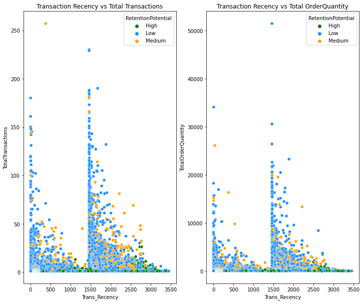

```python
fig, (ax1,ax2) = plt.subplots(1,2, figsize=(12,10))

ax1.set_title('Transaction Recency vs Total Transactions')
sns.scatterplot(data=custdata_train_y_trans, y="TotalTransactions",x='Trans_Recency',hue='RetentionPotential',ax=ax1,palette=['green','dodgerblue','orange'])

ax2.set_title('Transaction Recency vs Total OrderQuantity')
sns.scatterplot(data=custdata_train_y_trans, y="TotalOrderQuantity",x='Trans_Recency',hue='RetentionPotential',ax=ax2,palette=['green','dodgerblue','orange'])
plt.show()
```

Insights:

1. There are high and Medium level customers who has not done transactions for long time.
2. Different potential level customers are distributed every where with no particular pattern.
3. There are less transactions greater than 200 and orders greater than 25000, will consider them as outliers.

## 2.3 Email data

```python
emaildata_train
```

|  | CustomerID | DateOfemail | EmailType | timestamp | MailOpened | MailClicked |
| --- | --- | --- | --- | --- | --- | --- |
| 0 | C16368 | 2012-09-28 | WelcomeEmail | 15:56:50 | yes | NotApplicable |
| 1 | C20345 | 2010-12-19 | WelcomeEmail | 15:10:30 | yes | NotApplicable |
| 2 | C17683 | 2010-10-03 | WelcomeEmail | 17:12:24 | yes | NotApplicable |
| 3 | C18647 | 2010-11-27 | WelcomeEmail | 16:59:02 | yes | NotApplicable |
| 4 | C36692 | 2009-12-04 | WelcomeEmail | 17:27:22 | yes | NotApplicable |
| ... | ... | ... | ... | ... | ... | ... |
| 517667 | C36140 | 2018-01-18 | CustomizedEmail | 14:04:44 | yes | yes |
| 517668 | C36140 | 2018-01-21 | CustomizedEmail | 16:17:16 | no | no |
| 517669 | C36140 | 2018-01-20 | CustomizedEmail | 12:17:34 | yes | yes |
| 517670 | C36140 | 2018-01-20 | CustomizedEmail | 16:31:18 | yes | no |
| 517671 | C36140 | 2018-01-21 | CustomizedEmail | 14:23:16 | yes | yes |

517672 rows × 6 columns

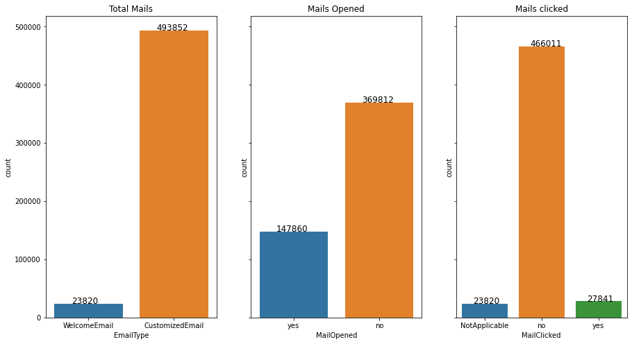

```python
fig, axes = plt.subplots(1, 3, figsize=(15, 8), sharey=True)

sns.countplot(emaildata_train.EmailType,ax=axes[0])
axes[0].set_title("Total Mails")
for p in axes[0].patches:
  axes[0].annotate(f'\n{p.get_height()}', (p.get_x()+0.2, p.get_height()), ha='left', va='baseline', color='black', size=12)

sns.countplot(emaildata_train.MailOpened,ax=axes[1])
axes[1].set_title("Mails Opened")
for p in axes[1].patches:
  ax=axes[1].annotate(f'\n{p.get_height()}', (p.get_x()+0.2, p.get_height()), ha='left', va='baseline', color='black', size=12)

sns.countplot(emaildata_train.MailClicked,ax=axes[2])
axes[2].set_title("Mails clicked")
for p in axes[2].patches:
  axes[2].annotate(f'\n{p.get_height()}', (p.get_x()+0.2, p.get_height()), ha='left', va='baseline', color='black', size=12)
```

1. Welcome email is sent to every customer after registration.
2. Welcome emails has Mail clicked field as Not applicable.
3. Less emails where opened.
4. Very less emailed where clicked by the customers.

### 2.3.1 Calculating the total emails sent to a customer.

```python
email_counts_train=pd.DataFrame(emaildata_train.groupby('CustomerID')['MailClicked'].count()).reset_index() # gives how many times a customer is contacted using groupby
email_counts_train.rename(columns={'MailClicked':'NoOfTimesContacted'},inplace=True)
email_counts_train

email_counts_test=pd.DataFrame(emaildata_test.groupby('CustomerID')['MailClicked'].count()).reset_index()  # gives how many times a customer is contacted using groupby
email_counts_test.rename(columns={'MailClicked':'NoOfTimesContacted'},inplace=True)
email_counts_test
```

|  | CustomerID | NoOfTimesContacted |
| --- | --- | --- |
| 0 | C12121 | 25 |
| 1 | C12132 | 1 |
| 2 | C12134 | 1 |
| 3 | C12135 | 30 |
| 4 | C12136 | 42 |
| ... | ... | ... |
| 5950 | C42153 | 11 |
| 5951 | C42155 | 1 |
| 5952 | C42157 | 1 |
| 5953 | C42167 | 50 |
| 5954 | C42190 | 1 |

5955 rows × 2 columns

```python
max(email_counts_train.NoOfTimesContacted),min(email_counts_train.NoOfTimesContacted)
```

```
(292, 1)
```

Minimum a customer was contacted is 1 and maximum a customer was contacted is 292.

```python
emaildata_train.sort_values('DateOfemail',inplace=True)
emaildata_test.sort_values('DateOfemail',inplace=True)

emaildata_train1=emaildata_train.copy()
emaildata_test1=emaildata_test.copy()
```

### 2.3.2 Calculating the total Mails clicked and Opened

Replacing the values of Mail clicked and Mail Opened with 1 and 0, such that it helps in calculating the counts for each customer.

```python
emaildata_train1.MailOpened.replace({'yes':1,'no':0},inplace=True) #replaces Mail clicked values 'Yes' and 'No' with 1 and 0 respectively
#replaces Mail Opened values 'Yes' and 'No' with 1 and 0 respectively and 'Not applicable' also with 0 as it is not considered as mail clicked.
emaildata_train1.MailClicked.replace({'yes':1,'no':0,'NotApplicable':0},inplace=True) #replaces Mail Opened values 'Yes' and 'No' with 1 and 0 respectively and 'Not app;icable

emaildata_test1.MailOpened.replace({'yes':1,'no':0},inplace=True)   #replaces Mail clicked values 'Yes' and 'No' with 1 and 0 respectively
#replaces Mail Opened values 'Yes' and 'No' with 1 and 0 respectively and 'Not applicable' also with 0 as it is not considered as mail clicked.
emaildata_test1.MailClicked.replace({'yes':1,'no':0,'NotApplicable':0},inplace=True)
```

```python
emaildata_test1
```

|  | CustomerID | DateOfemail | EmailType | timestamp | MailOpened | MailClicked |
| --- | --- | --- | --- | --- | --- | --- |
| 96 | C13990 | 2008-07-17 | WelcomeEmail | 15:09:26 | 1 | 0 |
| 8329 | C13990 | 2008-07-18 | CustomizedEmail | 16:55:20 | 0 | 0 |
| 8338 | C13990 | 2008-07-21 | CustomizedEmail | 17:42:08 | 0 | 0 |
| 30 | C41269 | 2008-07-21 | WelcomeEmail | 13:51:34 | 1 | 0 |
| 8318 | C13990 | 2008-07-22 | CustomizedEmail | 10:22:26 | 0 | 0 |
| ... | ... | ... | ... | ... | ... | ... |
| 125697 | C38187 | 2018-01-20 | CustomizedEmail | 11:40:46 | 0 | 0 |
| 128858 | C35843 | 2018-01-20 | CustomizedEmail | 14:41:12 | 0 | 0 |
| 127821 | C19960 | 2018-01-21 | CustomizedEmail | 15:55:12 | 0 | 0 |
| 129061 | C28149 | 2018-01-21 | CustomizedEmail | 17:07:26 | 1 | 1 |
| 129058 | C28149 | 2018-01-21 | CustomizedEmail | 12:15:42 | 0 | 0 |

129074 rows × 6 columns

```python
email_opened_counts_train=pd.DataFrame(emaildata_train1.groupby('CustomerID')['MailOpened'].sum()).reset_index()#Calculates Mail Opened counts for each customer
email_clicked_counts_train=pd.DataFrame(emaildata_train1.groupby('CustomerID')['MailClicked'].sum()).reset_index()#Calculates Mail Clicked counts for each customer

email_opened_counts_test=pd.DataFrame(emaildata_test1.groupby('CustomerID')['MailOpened'].sum()).reset_index()#Calculates Mail Opened counts for each customer
email_clicked_counts_test=pd.DataFrame(emaildata_test1.groupby('CustomerID')['MailClicked'].sum()).reset_index()#Calculates Mail Clicked counts for each customer
```

```python
email_opened_counts_train
```

|  | CustomerID | MailOpened |
| --- | --- | --- |
| 0 | C12116 | 5 |
| 1 | C12117 | 1 |
| 2 | C12118 | 1 |
| 3 | C12119 | 14 |
| 4 | C12120 | 1 |
| ... | ... | ... |
| 23815 | C42185 | 10 |
| 23816 | C42186 | 1 |
| 23817 | C42187 | 1 |
| 23818 | C42188 | 1 |
| 23819 | C42189 | 19 |

23820 rows × 2 columns

Function to merge different data frames

```python
def mergedf(df1,df2):
  df3=pd.merge(df1,df2,on='CustomerID',how='left')
  return df3
```

```python
emaildata_train_eng=mergedf(email_counts_train,email_opened_counts_train)
emaildata_train_eng1=mergedf(emaildata_train_eng,email_clicked_counts_train)
emaildata_train_eng1


emaildata_test_eng=mergedf(email_counts_test,email_opened_counts_test)
emaildata_test_eng1=mergedf(emaildata_test_eng,email_clicked_counts_test)
emaildata_test_eng1
```

|  | CustomerID | NoOfTimesContacted | MailOpened | MailClicked |
| --- | --- | --- | --- | --- |
| 0 | C12121 | 25 | 9 | 3 |
| 1 | C12132 | 1 | 1 | 0 |
| 2 | C12134 | 1 | 1 | 0 |
| 3 | C12135 | 30 | 9 | 5 |
| 4 | C12136 | 42 | 4 | 1 |
| ... | ... | ... | ... | ... |
| 5950 | C42153 | 11 | 3 | 1 |
| 5951 | C42155 | 1 | 1 | 0 |
| 5952 | C42157 | 1 | 1 | 0 |
| 5953 | C42167 | 50 | 4 | 1 |
| 5954 | C42190 | 1 | 1 | 0 |

5955 rows × 4 columns

### 2.3.3 Email Recency

Email recency of a customer is the number of days that has happend after a email has been sent to him.

```python
emaildata_train_Date=pd.DataFrame(emaildata_train2.groupby('CustomerID')['DateOfemail'].unique()).reset_index()
emaildata_test_Date=pd.DataFrame(emaildata_test2.groupby('CustomerID')['DateOfemail'].unique()).reset_index()
```

```python
emaildata_train_eng2=mergedf(emaildata_train_eng1,emaildata_train_Date)
emaildata_test_eng2=mergedf(emaildata_test_eng1,emaildata_test_Date)
```

```python
max(emaildata_train.DateOfemail),max(emaildata_test.DateOfemail)
```

[output not shown]

The last date is same.

```python
emaildata_train_eng2['Email_Recency']=[(last_date-pd.to_datetime(i[-1])).days for i in emaildata_train_eng2.DateOfemail]
emaildata_test_eng2['Email_Recency']=[(last_date-pd.to_datetime(i[-1])).days for i in emaildata_test_eng2.DateOfemail]
emaildata_train_eng2
```

|  | CustomerID | NoOfTimesContacted | MailOpened | MailClicked | DateOfemail | Email_Recency |
| --- | --- | --- | --- | --- | --- | --- |
| 0 | C12116 | 32 | 5 | 2 | [2013-09-23, 2013-09-24, 2013-09-26, 2013-09-2... | 1566 |
| 1 | C12117 | 1 | 1 | 0 | [2013-12-05] | 1509 |
| 2 | C12118 | 1 | 1 | 0 | [2013-09-10] | 1595 |
| 3 | C12119 | 42 | 14 | 4 | [2013-04-13, 2013-04-22, 2013-04-28, 2013-04-2... | 1554 |
| 4 | C12120 | 1 | 1 | 0 | [2014-01-10] | 1473 |
| ... | ... | ... | ... | ... | ... | ... |
| 23815 | C42185 | 44 | 10 | 0 | [2011-03-03, 2011-03-05, 2011-03-08, 2011-03-1... | 2215 |
| 23816 | C42186 | 1 | 1 | 0 | [2013-11-23] | 1521 |
| 23817 | C42187 | 1 | 1 | 0 | [2013-09-15] | 1590 |
| 23818 | C42188 | 1 | 1 | 0 | [2011-10-04] | 2302 |
| 23819 | C42189 | 51 | 19 | 0 | [2013-01-17, 2013-01-20, 2013-01-23, 2013-01-3... | 1539 |

23820 rows × 6 columns

### 2.3.4 Merging with customer data

```python
custdata_train_y_trans_email=mergedf(custdata_train_y_trans,emaildata_train_eng2)
custdata_test_trans_email=mergedf(custdata_test_trans,emaildata_test_eng2)
```

```python
custdata_train_y_trans_email
```

|  | CustomerID | City | DateOfRegistration | OnlineCommunication | AutomaticRefill | DoorstepDelivery | PreferredDeliveryDay | RetentionPotential | DateOfOrder | TotalTransactions | TotalOrderQuantity | Trans_Recency | NoOfTimesContacted | MailOpened | MailClicked | DateOfemail | Email_Recency |
| --- | --- | --- | --- | --- | --- | --- | --- | --- | --- | --- | --- | --- | --- | --- | --- | --- | --- |
| 0 | C16368 | CITY2 | 2012-09-28 | 0 | 0 | 0 | Monday | High | [2013-08-11] | 1 | 15 | 1625 | 30 | 30 | 1 | [2012-09-28, 2012-10-07, 2012-10-15, 2012-10-2... | 1642 |
| 1 | C20345 | CITY2 | 2010-12-19 | 1 | 1 | 1 | Friday | Low | [2011-04-01, 2011-04-02, 2011-04-09, 2011-04-1... | 186 | 15614 | 1464 | 96 | 89 | 10 | [2010-12-19, 2010-12-21, 2011-01-15, 2011-01-1... | 1495 |
| 2 | C17683 | CITY2 | 2010-10-03 | 0 | 0 | 0 | Wednesday | Medium | [2010-12-01, 2010-12-14, 2011-01-08, 2011-01-1... | 13 | 443 | 2392 | 1 | 1 | 0 | [2010-10-03] | 2668 |
| 3 | C18647 | CITY4 | 2010-11-27 | 0 | 0 | 0 | Monday | Low | [2010-11-29, 2011-02-28, 2011-05-11, 2011-12-1... | 7 | 748 | 1820 | 31 | 28 | 4 | [2010-11-27, 2011-02-10, 2011-02-11, 2011-03-1... | 1862 |
| 4 | C36692 | CITY2 | 2009-12-04 | 1 | 1 | 0 | Friday | Low | [2011-09-21, 2011-11-11, 2011-11-14, 2011-12-1... | 34 | 2350 | 1467 | 65 | 19 | 10 | [2009-12-04, 2009-12-24, 2010-01-23, 2010-01-2... | 1467 |
| ... | ... | ... | ... | ... | ... | ... | ... | ... | ... | ... | ... | ... | ... | ... | ... | ... | ... |
| 23815 | C23511 | CITY2 | 2018-01-17 | 1 | 1 | 0 | Friday | Low | [2018-01-17] | 1 | 41 | 5 | 1 | 1 | 0 | [2018-01-17] | 5 |
| 23816 | C12197 | CITY3 | 2018-01-17 | 1 | 0 | 1 | Friday | Low | [2018-01-17] | 1 | 56 | 5 | 1 | 1 | 0 | [2018-01-17] | 5 |
| 23817 | C40967 | CITY3 | 2018-01-17 | 1 | 0 | 0 | Saturday | Low | [2018-01-17] | 1 | 35 | 5 | 1 | 1 | 0 | [2018-01-17] | 5 |
| 23818 | C36140 | CITY3 | 2018-01-17 | 1 | 1 | 0 | Saturday | Low | [2018-01-17, 2018-01-21] | 2 | 100 | 1 | 9 | 7 | 3 | [2018-01-17, 2018-01-18, 2018-01-20, 2018-01-21] | 1 |
| 23819 | C42003 | CITY4 | 2018-01-17 | 1 | 0 | 0 | Friday | Low | [2018-01-17] | 1 | 41 | 5 | 1 | 1 | 0 | [2018-01-17] | 5 |

23820 rows × 17 columns

### 2.3.5 Visualizations on relation between total transactions and total emails.

```python
remoutliers=custdata_train_y_trans_email[(custdata_train_y_trans_email.NoOfTimesContacted<99) & (custdata_train_y_trans_email.TotalTransactions<200)]
High_Medium=custdata_train_y_trans_email[(custdata_train_y_trans_email.RetentionPotential!='Low')]
```

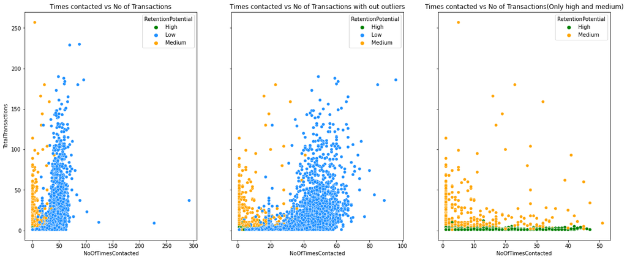

```python
fig, axes = plt.subplots(1, 3, figsize=(20, 8), sharey=True)

sns.scatterplot(data=custdata_train_y_trans_email, y="TotalTransactions",x='NoOfTimesContacted',hue='RetentionPotential',palette=['green','dodgerblue','orange'],ax=axes[0])
axes[0].set_title("Times contacted vs No of Transactions")

sns.scatterplot(data=remoutliers, y="TotalTransactions",x='NoOfTimesContacted',hue='RetentionPotential',palette=['green','dodgerblue','orange'],ax=axes[1])
axes[1].set_title("Times contacted vs No of Transactions with out outliers")


sns.scatterplot(data=High_Medium, y="TotalTransactions",x='NoOfTimesContacted',hue='RetentionPotential',palette=['green','orange'],ax=axes[2])
axes[2].set_title("Times contacted vs No of Transactions(Only high and medium)")
plt.show()
```

Insights:

1. We can see the medium retention potentital level customers have been sent less emails.
2. High retention potentital (Green)level customers have done less transactions compared to other customers.

### 2.3.6 Relation between how old a customer is and Retention Potential

```python
custdata_train_y_trans_email["Registration_Recency"]=[(last_date-pd.to_datetime(i)).days for i in custdata_train_y_trans_email.DateOfRegistration]
custdata_test_trans_email["Registration_Recency"]=[(last_date-pd.to_datetime(i)).days for i in custdata_test_trans_email.DateOfRegistration]
```

```python
High_Medium=custdata_train_y_trans_email[(custdata_train_y_trans_email.RetentionPotential!='Low')]
```

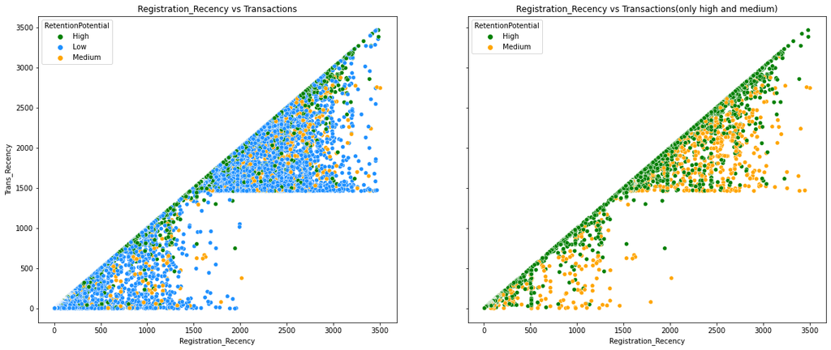

```python
fig, axes = plt.subplots(1, 2, figsize=(20, 8), sharey=True)

sns.scatterplot(data=custdata_train_y_trans_email, y="Trans_Recency",x='Registration_Recency',hue='RetentionPotential',palette=['green','dodgerblue','orange'],ax=axes[0])
axes[0].set_title("Registration_Recency vs Transactions")

sns.scatterplot(data=High_Medium, y="Trans_Recency",x='Registration_Recency',hue='RetentionPotential',palette=['green','orange'],ax=axes[1])
axes[1].set_title("Registration_Recency vs Transactions(only high and medium)")
plt.show()
```

Insights:

1. Though the customers are old and have not done any transactions for many days they are considered as high and Medium potential customers.( Need to find more.

## 2.4 To find why customers who are inactive for long time are also considered as high and Medium.

### 2.4.1 Customers who have done one transaction.

```python
custdata_train_y_trans_email.loc[custdata_train_y_trans_email.TotalTransactions==1,'RetentionPotential' ].value_counts()
```

```
Low       11843
High       3030
Medium       99
Name: RetentionPotential, dtype: int64
```

```python
custdata_train_y_trans_email.loc[custdata_train_y_trans_email.NoOfTimesContacted==1,'RetentionPotential' ].value_counts()
```

```
Low       6277
High      2897
Medium     535
Name: RetentionPotential, dtype: int64
```

Insights:

1. 62% of the customers have done only one transaction.
2. 40% of the customers have been contacted only once. 2.we can see out of 3756 high potential level customers, 3030( i.e 80% ) have done only one transactions.
3. 535 out of 879 Medium level customers(i.e 60%) have been contacted only once.

### 2.4.2 Customers who have done one transaction and contacted once.

```python
custdata_train_y_trans_email.loc[(custdata_train_y_trans_email.TotalTransactions==1) & (custdata_train_y_trans_email.NoOfTimesContacted==1),'RetentionPotential' ].value_counts()
```

```
Low       6277
High      2398
Medium      55
Name: RetentionPotential, dtype: int64
```

63% of Highly potential customers have been contacted only Once after they have done a transactions.

### 2.4.3 Customers who have done transactions greater than once and no of times contacted.

```python
custdata_train_y_trans_email.loc[(custdata_train_y_trans_email.TotalTransactions>1) & (custdata_train_y_trans_email.NoOfTimesContacted==1),'RetentionPotential' ].value_counts()
```

```
High      499
Medium    480
Name: RetentionPotential, dtype: int64
```

Insights:

54% of the Medium Level customers have done multiple transactions and have been contacted only once.

## 2.5 Findings:

1. I find that most of the Medium and high level customers have been contacted only once.
2. There is clearly a down side on interaction with the customers.

# 3 Data Cleaning

```python
custdata_train_y_trans_email
```

[output not shown]

23820 rows × 22 columns

```python
custdata_test_trans_email
```

[output not shown]

5955 rows × 21 columns

```python
train1=custdata_train_y_trans_email.copy()
test1=custdata_test_trans_email.copy()
```

```python
train1.columns
```

```
Index(['CustomerID', 'City', 'DateOfRegistration', 'OnlineCommunication',
       'AutomaticRefill', 'DoorstepDelivery', 'PreferredDeliveryDay',
       'RetentionPotential', 'DateOfOrder', 'TotalTransactions',
       'TotalOrderQuantity', 'Trans_Recency', 'NoOfTimesContacted',
       'MailOpened', 'MailClicked', 'DateOfemail', 'Email_Recency',
       'Registration_Recency'],
      dtype='object')
```

```python
train1.drop(columns=['CustomerID','DateOfRegistration','DateOfOrder','DateOfemail' ],inplace=True)
test1.drop(columns=['CustomerID','DateOfRegistration','DateOfOrder','DateOfemail' ],inplace=True)
```

1. Removing CustomerID as it is unique and will not help us in predicting the retention potential.
2. Removing all Dates as the information will be contained in the recency attributes like Trans_Recency,Email_Recency and Registration_Recency.

```python
train1
```

[output not shown]

23820 rows × 14 columns

# 4 Type Casting

```python
train1.dtypes
```

```
City                    object
OnlineCommunication      int64
AutomaticRefill          int64
DoorstepDelivery         int64
PreferredDeliveryDay    object
RetentionPotential      object
TotalTransactions        int64
TotalOrderQuantity       int64
Trans_Recency            int64
NoOfTimesContacted       int64
MailOpened               int64
MailClicked              int64
Email_Recency            int64
Registration_Recency     int64
dtype: object
```

```python
category_cols=['City', 'OnlineCommunication', 'AutomaticRefill', 'DoorstepDelivery','PreferredDeliveryDay']
for i in category_cols:
  train1[i]=train1[i].astype("category")
  test1[i]=test1[i].astype("category")
```

### 4.1 Replacing the target attributes with numericals.

```python
train1.RetentionPotential=train1.RetentionPotential.astype('category')
train1.RetentionPotential.replace({'Low':0,'Medium':1,'High':2},inplace=True)
```

```python
train1.dtypes
```

```
City                    category
OnlineCommunication     category
AutomaticRefill         category
DoorstepDelivery        category
PreferredDeliveryDay    category
RetentionPotential         int64
TotalTransactions          int64
TotalOrderQuantity         int64
Trans_Recency              int64
NoOfTimesContacted         int64
MailOpened                 int64
MailClicked                int64
Email_Recency              int64
Registration_Recency       int64
dtype: object
```

# 5 Label Encoding

```python
lab_labels=['City', 'OnlineCommunication', 'AutomaticRefill', 'DoorstepDelivery','PreferredDeliveryDay']
def labelencoding(X):
  for i in range(0,len(X.columns)):
      j=X.columns[i]
      if(j in lab_labels):
          le = LabelEncoder()                  # converts the character array to numeric array. Assigns levels to unique labels.
          le.fit(X[j])
          X[j] = le.transform(X[j])
          X[j]=X[j].astype('category')
  return X
```

```python
train2=labelencoding(train1).copy()
test2=labelencoding(test1).copy()
```

```python
train2
```

|  | City | OnlineCommunication | AutomaticRefill | DoorstepDelivery | PreferredDeliveryDay | RetentionPotential | TotalTransactions | TotalOrderQuantity | Trans_Recency | NoOfTimesContacted | MailOpened | MailClicked | Email_Recency | Registration_Recency |
| --- | --- | --- | --- | --- | --- | --- | --- | --- | --- | --- | --- | --- | --- | --- |
| 0 | 1 | 0 | 0 | 0 | 1 | 2 | 1 | 15 | 1625 | 30 | 30 | 1 | 1642 | 1942 |
| 1 | 1 | 1 | 1 | 1 | 0 | 0 | 186 | 15614 | 1464 | 96 | 89 | 10 | 1495 | 2591 |
| 2 | 1 | 0 | 0 | 0 | 6 | 1 | 13 | 443 | 2392 | 1 | 1 | 0 | 2668 | 2668 |
| 3 | 3 | 0 | 0 | 0 | 1 | 0 | 7 | 748 | 1820 | 31 | 28 | 4 | 1862 | 2613 |
| 4 | 1 | 1 | 1 | 0 | 0 | 0 | 34 | 2350 | 1467 | 65 | 19 | 10 | 1467 | 2971 |
| ... | ... | ... | ... | ... | ... | ... | ... | ... | ... | ... | ... | ... | ... | ... |
| 23815 | 1 | 1 | 1 | 0 | 0 | 0 | 1 | 41 | 5 | 1 | 1 | 0 | 5 | 5 |
| 23816 | 2 | 1 | 0 | 1 | 0 | 0 | 1 | 56 | 5 | 1 | 1 | 0 | 5 | 5 |
| 23817 | 2 | 1 | 0 | 0 | 2 | 0 | 1 | 35 | 5 | 1 | 1 | 0 | 5 | 5 |
| 23818 | 2 | 1 | 1 | 0 | 2 | 0 | 2 | 100 | 1 | 9 | 7 | 3 | 1 | 5 |
| 23819 | 3 | 1 | 0 | 0 | 0 | 0 | 1 | 41 | 5 | 1 | 1 | 0 | 5 | 5 |

23820 rows × 14 columns

# 6 Scaling

```python
train2.columns
```

```
Index(['City', 'OnlineCommunication', 'AutomaticRefill', 'DoorstepDelivery',
       'PreferredDeliveryDay', 'RetentionPotential', 'TotalTransactions',
       'TotalOrderQuantity', 'Trans_Recency', 'NoOfTimesContacted',
       'MailOpened', 'MailClicked', 'Email_Recency', 'Registration_Recency'],
      dtype='object')
```

```python
num_cols=['TotalTransactions','TotalOrderQuantity', 'NoOfTimesContacted', 'MailOpened', 'MailClicked', 'Email_Recency', 'Registration_Recency','Trans_Recency']
```

```python
standscaler=StandardScaler()
def scaler(data):
  X=data.copy()
  for i in num_cols:
    X[i]=standscaler.fit_transform(np.array(X[i]).reshape(-1,1))
  return X
```

```python
train3=scaler(train2).copy()
test3=scaler(test2).copy()
```

```python
train3
```

|  | City | OnlineCommunication | AutomaticRefill | DoorstepDelivery | PreferredDeliveryDay | RetentionPotential | TotalTransactions | TotalOrderQuantity | Trans_Recency | NoOfTimesContacted | MailOpened | MailClicked | Email_Recency | Registration_Recency |
| --- | --- | --- | --- | --- | --- | --- | --- | --- | --- | --- | --- | --- | --- | --- |
| 0 | 1 | 0 | 0 | 0 | 1 | 2 | -0.279748 | -0.256527 | 0.292479 | 0.412539 | 2.793470 | -0.071047 | 0.284304 | 0.533192 |
| 1 | 1 | 1 | 1 | 1 | 0 | 0 | 14.958762 | 11.422679 | 0.054142 | 3.705932 | 9.720608 | 3.716813 | 0.070451 | 1.431422 |
| 2 | 1 | 0 | 0 | 0 | 6 | 1 | 0.708696 | 0.063923 | 1.427907 | -1.034557 | -0.611395 | -0.491920 | 1.776915 | 1.537992 |
| 3 | 3 | 0 | 0 | 0 | 1 | 0 | 0.214474 | 0.292281 | 0.581147 | 0.462439 | 2.558651 | 1.191573 | 0.604357 | 1.461870 |
| 4 | 1 | 1 | 1 | 0 | 0 | 0 | 2.438473 | 1.491723 | 0.058583 | 2.159035 | 1.501969 | 3.716813 | 0.029717 | 1.957350 |
| ... | ... | ... | ... | ... | ... | ... | ... | ... | ... | ... | ... | ... | ... | ... |
| 23815 | 1 | 1 | 1 | 0 | 0 | 0 | -0.279748 | -0.237060 | -2.105687 | -1.034557 | -0.611395 | -0.491920 | -2.097181 | -2.147657 |
| 23816 | 2 | 1 | 0 | 1 | 0 | 0 | -0.279748 | -0.225830 | -2.105687 | -1.034557 | -0.611395 | -0.491920 | -2.097181 | -2.147657 |
| 23817 | 2 | 1 | 0 | 0 | 2 | 0 | -0.279748 | -0.241553 | -2.105687 | -1.034557 | -0.611395 | -0.491920 | -2.097181 | -2.147657 |
| 23818 | 2 | 1 | 1 | 0 | 2 | 0 | -0.197378 | -0.192886 | -2.111609 | -0.635358 | 0.093060 | 0.770700 | -2.103000 | -2.147657 |
| 23819 | 3 | 1 | 0 | 0 | 0 | 0 | -0.279748 | -0.237060 | -2.105687 | -1.034557 | -0.611395 | -0.491920 | -2.097181 | -2.147657 |

23820 rows × 14 columns

# 7 Segmentation

## 7.1 K-Means clustering

```python
train3.columns
```

```
Index(['City', 'OnlineCommunication', 'AutomaticRefill', 'DoorstepDelivery',
       'PreferredDeliveryDay', 'RetentionPotential', 'TotalTransactions',
       'TotalOrderQuantity', 'Trans_Recency', 'NoOfTimesContacted',
       'MailOpened', 'MailClicked', 'Email_Recency', 'Registration_Recency'],
      dtype='object')
```

```python
cols_for_seg=['TotalTransactions','TotalOrderQuantity', 'Trans_Recency', 'NoOfTimesContacted', 'MailClicked', 'Email_Recency', 'Registration_Recency']
```

```python
clus=train3[cols_for_seg]
clus_test=test3[cols_for_seg]
```

### 7.1.1 choosing k number

As we already know we want three groups of customers, i am taking the k- value as 3 and no methods where performed to choose k value.

```python
model = KMeans(n_clusters=3, random_state=42)
model.fit(clus)
```

```
KMeans(algorithm='auto', copy_x=True, init='k-means++', max_iter=300,
       n_clusters=3, n_init=10, n_jobs=None, precompute_distances='auto',
       random_state=42, tol=0.0001, verbose=0)
```

I wanted to use and see if the clusters produced by the KMeans algorithm will help me predicting the potential levels. so i have added it to the train and test dataframe.

```python
train3['Cluster']=model.labels_
test3['Cluster']=model.predict(clus_test)
```

```python
custdata_train_y_trans_email['Cluster']=model.labels_
custdata_test_trans_email['Cluster']=model.predict(clus_test)
```

```python
train3.Cluster,test3.Cluster
```

```
(0        0
 1        2
 2        0
 3        0
 4        2
         ..
 23815    1
 23816    1
 23817    1
 23818    1
 23819    1
 Name: Cluster, Length: 23820, dtype: int32, 0       0
 1       2
 2       2
 3       0
 4       2
        ..
 5950    1
 5951    1
 5952    1
 5953    1
 5954    1
 Name: Cluster, Length: 5955, dtype: int32)
```

# 8 Modeling

## 8.1 Train Test Split

```python
X_train,X_valid,y_train,y_valid=train_test_split(train3.drop(columns='RetentionPotential'),train3.RetentionPotential,test_size=0.3,random_state=42)
```

```python
X_train.shape,X_valid.shape
```

```
((16674, 14), (7146, 14))
```

```python
y_train.value_counts(normalize=True),y_valid.value_counts(normalize=True)
```

```
(0    0.806225
 2    0.157071
 1    0.036704
 Name: RetentionPotential, dtype: float64, 0    0.803526
 2    0.159110
 1    0.037364
 Name: RetentionPotential, dtype: float64)
```

## 8.2 Decision Trees

```python
dt=DecisionTreeClassifier()
dt.fit(X_train,y_train)
```

```
DecisionTreeClassifier(ccp_alpha=0.0, class_weight=None, criterion='gini',
                       max_depth=None, max_features=None, max_leaf_nodes=None,
                       min_impurity_decrease=0.0, min_impurity_split=None,
                       min_samples_leaf=1, min_samples_split=2,
                       min_weight_fraction_leaf=0.0, presort='deprecated',
                       random_state=None, splitter='best')
```

```python
train_predict_dt=dt.predict(X_train)
test_predict_dt=dt.predict(X_valid)
print(classification_report(y_train,train_predict_dt))
print(classification_report(y_valid,test_predict_dt))
```

```
              precision    recall  f1-score   support

           0       0.99      1.00      0.99     13443
           1       1.00      0.98      0.99       612
           2       0.98      0.93      0.96      2619

    accuracy                           0.99     16674
   macro avg       0.99      0.97      0.98     16674
weighted avg       0.99      0.99      0.99     16674

              precision    recall  f1-score   support

           0       0.92      0.92      0.92      5742
           1       0.81      0.78      0.80       267
           2       0.64      0.63      0.63      1137

    accuracy                           0.87      7146
   macro avg       0.79      0.78      0.78      7146
weighted avg       0.87      0.87      0.87      7146
```

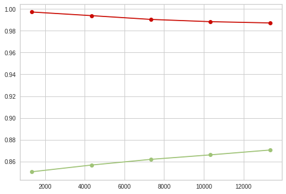

```python
from sklearn.model_selection import learning_curve
train_sizes, train_scores, test_scores, fit_times, _ = learning_curve(dt, X_train, y_train, cv=5,return_times=True,scoring='recall_weighted')
plt.plot(train_sizes,np.mean(train_scores,axis=1),'o-', color="r",label='train')
plt.plot(train_sizes,np.mean(test_scores,axis=1),'o-', color="g",label='validation')
plt.show()
```

The model has high recall on train data and less recall on validation data. Also as there is class imbalance problem in the data, the model is trying to predict the highest samples label more.

Trying Random forest with balanced class weight.

## 8.3 RandomForest()

```python
rf=RandomForestClassifier()
rf.fit(X_train,y_train)
train_predict_rf=rf.predict(X_train)
test_predict_rf=rf.predict(X_valid)
print(classification_report(y_train,train_predict_rf))
print(classification_report(y_valid,test_predict_rf))
```

```
              precision    recall  f1-score   support

           0       0.99      0.99      0.99     13443
           1       1.00      0.98      0.99       612
           2       0.97      0.94      0.96      2619

    accuracy                           0.99     16674
   macro avg       0.99      0.97      0.98     16674
weighted avg       0.99      0.99      0.99     16674

              precision    recall  f1-score   support

           0       0.93      0.95      0.94      5742
           1       0.89      0.72      0.80       267
           2       0.69      0.65      0.67      1137

    accuracy                           0.89      7146
   macro avg       0.84      0.77      0.80      7146
weighted avg       0.89      0.89      0.89      7146
```

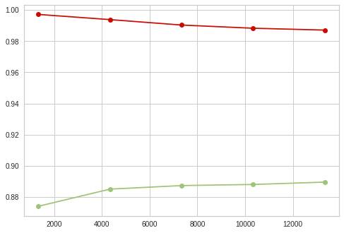

```python
train_sizes, train_scores, test_scores, fit_times, _ = learning_curve(rf, X_train, y_train, cv=5,return_times=True,scoring='recall_weighted')
plt.plot(train_sizes,np.mean(train_scores,axis=1),'o-', color="r",label='train')
plt.plot(train_sizes,np.mean(test_scores,axis=1),'o-', color="g",label='validation')
plt.show()
```

Same problem.

### 8.3.1 Addressing the class imbalance problem with class_weight in Random forest.

```python
rf=RandomForestClassifier(class_weight='balanced')
rf.fit(X_train,y_train)
```

```
RandomForestClassifier(bootstrap=True, ccp_alpha=0.0, class_weight='balanced',
                       criterion='gini', max_depth=None, max_features='auto',
                       max_leaf_nodes=None, max_samples=None,
                       min_impurity_decrease=0.0, min_impurity_split=None,
                       min_samples_leaf=1, min_samples_split=2,
                       min_weight_fraction_leaf=0.0, n_estimators=100,
                       n_jobs=None, oob_score=False, random_state=None,
                       verbose=0, warm_start=False)
```

```python
train_predict_rf=rf.predict(X_train)
test_predict_rf=rf.predict(X_valid)
```

```python
print(classification_report(y_train,train_predict_rf))
print(classification_report(y_valid,test_predict_rf))
```

```
              precision    recall  f1-score   support

           0       1.00      0.98      0.99     13443
           1       0.97      1.00      0.99       612
           2       0.92      0.98      0.95      2619

    accuracy                           0.98     16674
   macro avg       0.96      0.99      0.98     16674
weighted avg       0.98      0.98      0.98     16674

              precision    recall  f1-score   support

           0       0.92      0.94      0.93      5742
           1       0.90      0.75      0.82       267
           2       0.67      0.64      0.66      1137

    accuracy                           0.88      7146
   macro avg       0.83      0.78      0.80      7146
weighted avg       0.88      0.88      0.88      7146
```

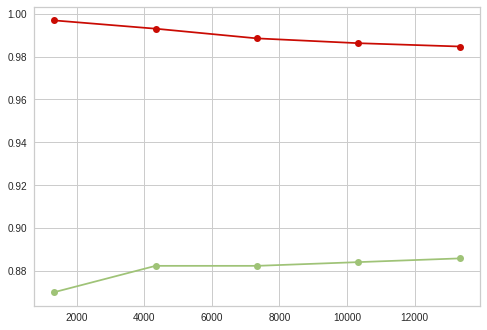

```python
train_sizes, train_scores, test_scores, fit_times, _ = learning_curve(rf, X_train, y_train, cv=5,return_times=True,scoring='recall_weighted')
plt.plot(train_sizes,np.mean(train_scores,axis=1),'o-', color="r",label='train')
plt.plot(train_sizes,np.mean(test_scores,axis=1),'o-', color="g",label='validation')
plt.show()
```

# Using SMOTE oversampling to handle the class imbalance problem.

```python
oversample=SMOTE()
train_X_Over,train_y_Over=oversample.fit_resample(X_train,y_train)
```

### 8.3.2 Random Forest Hypertuning-1

```python
rf_param_grid = { 'max_depth': [8,10,12,14],
                 "min_samples_split": [2, 10, 20],"min_samples_leaf": [1, 5, 10]}
rf_paramtuned = GridSearchCV(RandomForestClassifier(), param_grid=rf_param_grid, cv=5)
rf_paramtuned.fit(train_X_Over,train_y_Over)
```

```
GridSearchCV(cv=5, error_score=nan,
             estimator=RandomForestClassifier(bootstrap=True, ccp_alpha=0.0,
                                              class_weight=None,
                                              criterion='gini', max_depth=None,
                                              max_features='auto',
                                              max_leaf_nodes=None,
                                              max_samples=None,
                                              min_impurity_decrease=0.0,
                                              min_impurity_split=None,
                                              min_samples_leaf=1,
                                              min_samples_split=2,
                                              min_weight_fraction_leaf=0.0,
                                              n_estimators=100, n_jobs=None,
                                              oob_score=False,
                                              random_state=None, verbose=0,
                                              warm_start=False),
             iid='deprecated', n_jobs=None,
             param_grid={'max_depth': [8, 10, 12, 14],
                         'min_samples_leaf': [1, 5, 10],
                         'min_samples_split': [2, 10, 20]},
             pre_dispatch='2*n_jobs', refit=True, return_train_score=False,
             scoring=None, verbose=0)
```

```python
train_sizes, train_scores, test_scores, fit_times, _ = learning_curve(rf_paramtuned, X_train, y_train, cv=5,return_times=True,scoring='recall_weighted')
plt.plot(train_sizes,np.mean(train_scores,axis=1),'o-', color="r",label='train')
plt.plot(train_sizes,np.mean(test_scores,axis=1),'o-', color="g",label='validation')
plt.show()
```

[output not shown]

```python
rf_paramtuned.best_params_
```

```
{'max_depth': 14, 'min_samples_leaf': 1, 'min_samples_split': 2}
```

Changing the parameters as per the above best parameters and retuning the model to see the accurate best hyperparameters.

### 8.3.3 Random Forest Hypertuning-2

```python
rf_param_grid2 = { 'max_depth': [14,15],
                 "min_samples_split": [1,2,3],"min_samples_leaf": [1, 2]}
rf_paramtuned2 = GridSearchCV(RandomForestClassifier(), param_grid=rf_param_grid, cv=5)
rf_paramtuned2.fit(train_X_Over,train_y_Over)
```

```
GridSearchCV(cv=5, error_score=nan,
             estimator=RandomForestClassifier(bootstrap=True, ccp_alpha=0.0,
                                              class_weight=None,
                                              criterion='gini', max_depth=None,
                                              max_features='auto',
                                              max_leaf_nodes=None,
                                              max_samples=None,
                                              min_impurity_decrease=0.0,
                                              min_impurity_split=None,
                                              min_samples_leaf=1,
                                              min_samples_split=2,
                                              min_weight_fraction_leaf=0.0,
                                              n_estimators=100, n_jobs=None,
                                              oob_score=False,
                                              random_state=None, verbose=0,
                                              warm_start=False),
             iid='deprecated', n_jobs=None,
             param_grid={'max_depth': [8, 10, 12, 14],
                         'min_samples_leaf': [1, 5, 10],
                         'min_samples_split': [2, 10, 20]},
             pre_dispatch='2*n_jobs', refit=True, return_train_score=False,
             scoring=None, verbose=0)
```

```python
rf_paramtuned2.best_params_
```

```
{'max_depth': 14, 'min_samples_leaf': 1, 'min_samples_split': 2}
```

```python
train_sizes, train_scores, test_scores, fit_times, _ = learning_curve(rf_paramtuned2, X_train, y_train, cv=5,return_times=True,scoring='recall_weighted')
plt.plot(train_sizes,np.mean(train_scores,axis=1),'o-', color="r",label='train')
plt.plot(train_sizes,np.mean(test_scores,axis=1),'o-', color="g",label='validation')
plt.show()
```

[output not shown]

```python
train_predict_rf_tuned=rf_paramtuned2.predict(X_train)
test_predict_rf_tuned=rf_paramtuned2.predict(X_valid)
print(classification_report(y_train,train_predict_rf_tuned))
print(classification_report(y_valid,test_predict_rf_tuned))
```

```
              precision    recall  f1-score   support

           0       0.99      0.85      0.92     13443
           1       0.79      1.00      0.88       612
           2       0.58      0.94      0.71      2619

    accuracy                           0.87     16674
   macro avg       0.78      0.93      0.84     16674
weighted avg       0.92      0.87      0.88     16674

              precision    recall  f1-score   support

           0       0.97      0.83      0.89      5742
           1       0.70      0.84      0.76       267
           2       0.51      0.86      0.64      1137

    accuracy                           0.83      7146
   macro avg       0.73      0.84      0.77      7146
weighted avg       0.88      0.83      0.85      7146
```

## 8.4 LGBM

Implementing lgbm directly on Oversampled data.

```python
lg=LGBMClassifier()
lg.fit(train_X_Over,train_y_Over)
```

```
LGBMClassifier(boosting_type='gbdt', class_weight=None, colsample_bytree=1.0,
               importance_type='split', learning_rate=0.1, max_depth=-1,
               min_child_samples=20, min_child_weight=0.001, min_split_gain=0.0,
               n_estimators=100, n_jobs=-1, num_leaves=31, objective=None,
               random_state=None, reg_alpha=0.0, reg_lambda=0.0, silent=True,
               subsample=1.0, subsample_for_bin=200000, subsample_freq=0)
```

```python
predict_train_lg=lg.predict(X_train)
predict_test_lg=lg.predict(X_valid)
print(classification_report(y_train,predict_train_lg))
print(classification_report(y_valid,predict_test_lg))
```

```
              precision    recall  f1-score   support

           0       0.98      0.86      0.92     13443
           1       0.85      0.96      0.90       612
           2       0.58      0.90      0.70      2619

    accuracy                           0.87     16674
   macro avg       0.80      0.91      0.84     16674
weighted avg       0.91      0.87      0.88     16674

              precision    recall  f1-score   support

           0       0.97      0.84      0.90      5742
           1       0.79      0.87      0.83       267
           2       0.53      0.86      0.66      1137

    accuracy                           0.85      7146
   macro avg       0.76      0.86      0.80      7146
weighted avg       0.89      0.85      0.86      7146
```

```python
lg_param_grid = { 'max_depth': [11,12,13],
                 "min_samples_split": [2,5,10],"min_samples_leaf": [1,3,5]}
lg_paramtuned1 = GridSearchCV(LGBMClassifier(), param_grid=lg_param_grid, cv=5)
lg_paramtuned1.fit(train_X_Over,train_y_Over)
```

[output not shown]

```python
lg_paramtuned1.best_params_
```

```
{'max_depth': 12, 'min_samples_leaf': 1, 'min_samples_split': 2}
```

```python
predict_train_lg1=lg_paramtuned1.predict(X_train)
predict_test_lg1=lg_paramtuned1.predict(X_valid)
print(classification_report(y_train,predict_train_lg1))
print(classification_report(y_valid,predict_test_lg1))
```

[output not shown]

The recall score for medium level of tuned model is less when compared to normal model.

```python
from sklearn.svm import SVC
from sklearn.ensemble import AdaBoostClassifier
```

```python
svc=SVC()
svc.fit(train_X_Over,train_y_Over)
```

```
SVC(C=1.0, break_ties=False, cache_size=200, class_weight=None, coef0=0.0,
    decision_function_shape='ovr', degree=3, gamma='scale', kernel='rbf',
    max_iter=-1, probability=False, random_state=None, shrinking=True,
    tol=0.001, verbose=False)
```

```python
predict_train_svc1=svc.predict(X_train)
predict_test_svc1=svc.predict(X_valid)
print(classification_report(y_train,predict_train_svc1))
print(classification_report(y_valid,predict_test_svc1))
```

```
              precision    recall  f1-score   support

           0       0.98      0.66      0.79     13443
           1       0.41      0.88      0.56       612
           2       0.37      0.90      0.53      2619

    accuracy                           0.70     16674
   macro avg       0.59      0.81      0.62     16674
weighted avg       0.86      0.70      0.74     16674

              precision    recall  f1-score   support

           0       0.98      0.64      0.77      5742
           1       0.40      0.82      0.54       267
           2       0.36      0.90      0.52      1137

    accuracy                           0.69      7146
   macro avg       0.58      0.79      0.61      7146
weighted avg       0.86      0.69      0.72      7146
```

The recall score for medium level is not good.

## 8.5 AdaBoost

```python
ada=AdaBoostClassifier()
ada.fit(X_train,y_train)
predict_train_ada1=ada.predict(X_train)
predict_test_ada1=ada.predict(X_valid)
print(classification_report(y_train,predict_train_ada1))
print(classification_report(y_valid,predict_test_ada1))
```

```
              precision    recall  f1-score   support

           0       0.94      0.90      0.92     13443
           1       0.82      0.76      0.79       612
           2       0.59      0.73      0.65      2619

    accuracy                           0.87     16674
   macro avg       0.78      0.80      0.79     16674
weighted avg       0.88      0.87      0.87     16674

              precision    recall  f1-score   support

           0       0.94      0.89      0.91      5742
           1       0.84      0.76      0.80       267
           2       0.56      0.72      0.63      1137

    accuracy                           0.86      7146
   macro avg       0.78      0.79      0.78      7146
weighted avg       0.87      0.86      0.86      7146
```

# Trying RandomOverSampler for handling class imbalance

```python
oversample = RandomOverSampler(sampling_strategy={1:16674  ,0:16674,2:16674})
X_train_Ran201,y_train_Ran201=oversample.fit_resample(X_train,y_train)
```

```python
lgran201=LGBMClassifier()
lgran201.fit(X_train_Ran201,y_train_Ran201)
predict_train_lgran201=lgran201.predict(X_train)
predict_test_lgran201=lgran201.predict(X_valid)
print(classification_report(y_train,predict_train_lgran201))
print(classification_report(y_valid,predict_test_lgran201))
```

```
              precision    recall  f1-score   support

           0       0.99      0.84      0.91     13443
           1       0.80      1.00      0.89       612
           2       0.55      0.94      0.70      2619

    accuracy                           0.86     16674
   macro avg       0.78      0.93      0.83     16674
weighted avg       0.91      0.86      0.87     16674

              precision    recall  f1-score   support

           0       0.97      0.82      0.89      5742
           1       0.74      0.92      0.82       267
           2       0.51      0.90      0.65      1137

    accuracy                           0.84      7146
   macro avg       0.74      0.88      0.79      7146
weighted avg       0.89      0.84      0.85      7146
```

The recall score got is the best till now.

## 8.6 Nueral Nets

```python
import tensorflow
from tensorflow.keras.utils import to_categorical
from keras.utils import np_utils
from keras.models import Sequential
from keras.layers import Dense, Dropout
from keras.callbacks import EarlyStopping
from keras.wrappers.scikit_learn import KerasClassifier
from keras.optimizers import Adam
```

```python
encoded_y=LabelEncoder().fit_transform(y_train)

dummy_y=np_utils.to_categorical(encoded_y)
```

```python
dummy_y=np_utils.to_categorical(y_train)
```

```python
model = Sequential()
model.add(Dense(256, input_shape=(X_train.shape[1],), activation='relu'))
model.add(Dense(128,activation='relu'))
model.add(Dense(64,activation='relu'))
model.add(Dense(32,activation='relu'))
model.add(Dense(16,activation='relu'))
model.add(Dense(8,activation='relu'))
model.add(Dense(3, activation='softmax'))
model.summary()

# compile the model
model.compile(optimizer=Adam(0.0001),
              loss='categorical_crossentropy', # this is different instead of binary_crossentropy (for regular classification)
              metrics=[tensorflow.keras.metrics.Recall(name='recall')])
```

```
Model: "sequential_2"
_________________________________________________________________
Layer (type)                 Output Shape              Param #
=================================================================
dense_14 (Dense)             (None, 256)               3840
_________________________________________________________________
dense_15 (Dense)             (None, 128)               32896
_________________________________________________________________
dense_16 (Dense)             (None, 64)                8256
_________________________________________________________________
dense_17 (Dense)             (None, 32)                2080
_________________________________________________________________
dense_18 (Dense)             (None, 16)                528
_________________________________________________________________
dense_19 (Dense)             (None, 8)                 136
_________________________________________________________________
dense_20 (Dense)             (None, 3)                 27
=================================================================
Total params: 47,763
Trainable params: 47,763
Non-trainable params: 0
_________________________________________________________________
```

```python
perceptron_model_history = model.fit(X_train, dummy_y, epochs=200, batch_size=128, validation_split=0.3)
```

```python
y_train_predict_NN=model.predict(X_train)
y_valid_predict_NN=model.predict(X_valid)
y_valid_predict_NN.argmax(axis=1)
```

```
array([0, 0, 0, ..., 0, 0, 0])
```

```python
(unique, counts) = np.unique(y_valid_predict_NN.argmax(axis=1), return_counts=True)
frequencies = np.asarray((unique, counts)).T
frequencies
```

```
array([[   0, 6220],
       [   1,  205],
       [   2,  721]])
```

```python
print(classification_report(dummy_y.argmax(axis=1),y_train_predict_NN.argmax(axis=1)))
print(classification_report(dummy_y_valid.argmax(axis=1),y_valid_predict_NN.argmax(axis=1)))
```

```
              precision    recall  f1-score   support

           0       0.91      0.98      0.94     13443
           1       0.93      0.73      0.82       612
           2       0.81      0.50      0.62      2619

    accuracy                           0.90     16674
   macro avg       0.88      0.74      0.79     16674
weighted avg       0.89      0.90      0.89     16674

              precision    recall  f1-score   support

           0       0.90      0.97      0.93      5742
           1       0.84      0.65      0.73       267
           2       0.74      0.47      0.57      1137

    accuracy                           0.88      7146
   macro avg       0.83      0.70      0.75      7146
weighted avg       0.87      0.88      0.87      7146
```

# Predicting on the Test data using the best model.

so far i have good score on the LGBM model with Random Over sampling, using the same model to predict the test scores.

```python
test_lg=lgran201.predict(test3)
test_lg_df=pd.DataFrame({'CustomerID':test['CustomerID'],'RetentionPotential':test_lg})
test_lg_df
```

|  | CustomerID | RetentionPotential |
| --- | --- | --- |
| 0 | C12121 | 2 |
| 1 | C12132 | 0 |
| 2 | C12134 | 0 |
| 3 | C12135 | 0 |
| 4 | C12136 | 1 |
| ... | ... | ... |
| 5950 | C42153 | 0 |
| 5951 | C42155 | 0 |
| 5952 | C42157 | 0 |
| 5953 | C42167 | 0 |
| 5954 | C42190 | 0 |

5955 rows × 2 columns

```python
test_lg_df.to_csv("Classification4_3592.csv")
```

# 9 Extracting Rules

## 9.1 Using Decision Tree

```python
dt=DecisionTreeClassifier(max_depth=3)
dt.fit(X_train,y_train)
```

```
DecisionTreeClassifier(ccp_alpha=0.0, class_weight=None, criterion='gini',
                       max_depth=3, max_features=None, max_leaf_nodes=None,
                       min_impurity_decrease=0.0, min_impurity_split=None,
                       min_samples_leaf=1, min_samples_split=2,
                       min_weight_fraction_leaf=0.0, presort='deprecated',
                       random_state=None, splitter='best')
```

```python
y_train.replace({0:'Low',1:'Medium',2:'High'},inplace=True)
```

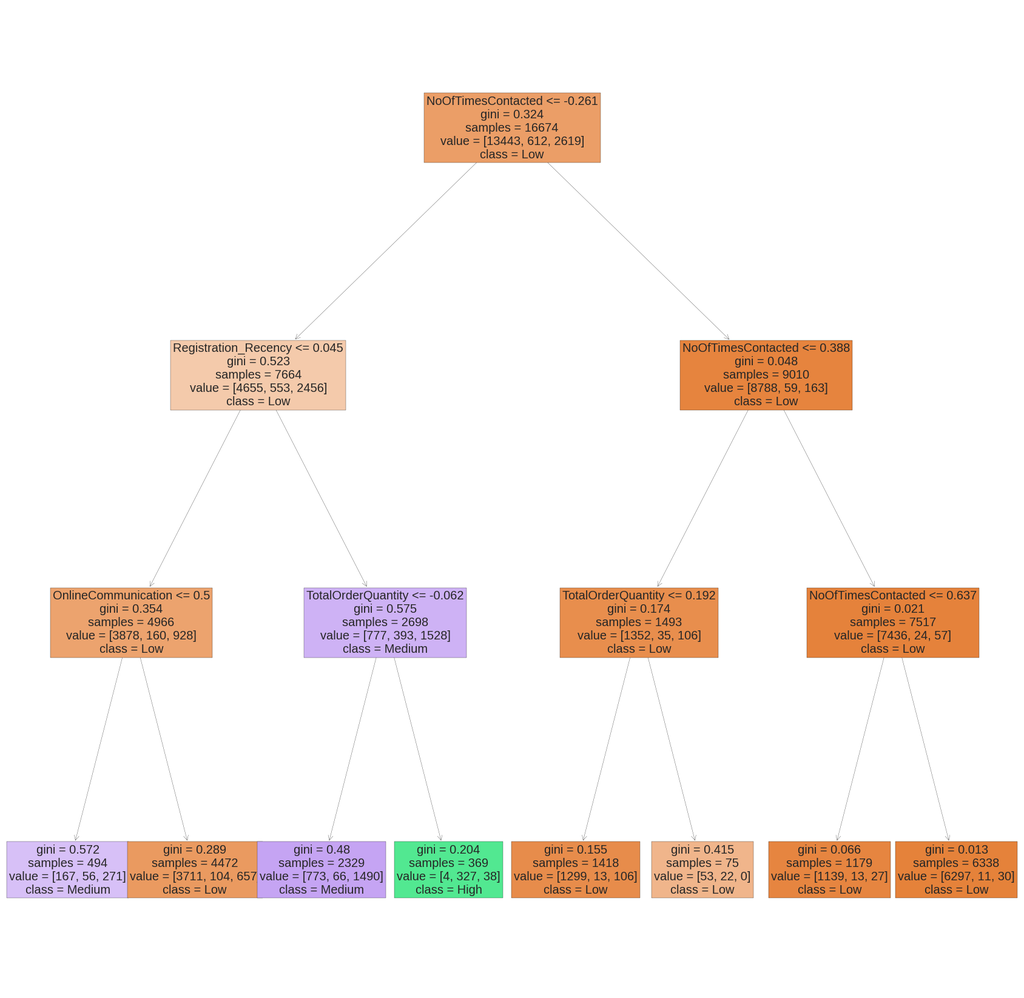

```python
plt.figure(figsize=(30,30))
tree.plot_tree(dt,fontsize=20,feature_names=X_train.columns,
                   class_names=y_train.unique(),
                   filled=True)
plt.show()
```

## 9.2 Using LGBM Tree

```python
m=LGBMClassifier()
m.fit(train2.drop(columns='RetentionPotential'),train2.RetentionPotential)
```

```
LGBMClassifier(boosting_type='gbdt', class_weight=None, colsample_bytree=1.0,
               importance_type='split', learning_rate=0.1, max_depth=-1,
               min_child_samples=20, min_child_weight=0.001, min_split_gain=0.0,
               n_estimators=100, n_jobs=-1, num_leaves=31, objective=None,
               random_state=None, reg_alpha=0.0, reg_lambda=0.0, silent=True,
               subsample=1.0, subsample_for_bin=200000, subsample_freq=0)
```

```python
import lightgbm
```

[figure not shown]

```python
lightgbm.plot_tree(m,figsize=(100,100))
plt.show()
```

```python
499/23820
```

```
0.020948782535684298
```

```python
custdata_train_y_trans_email.loc[(custdata_train_y_trans_email.TotalTransactions>1) & (custdata_train_y_trans_email.NoOfTimesContacted==1),'RetentionPotential'].value_counts()
```

```
High      499
Medium    480
Name: RetentionPotential, dtype: int64
```

## Patterns

High:

1. If the TotalTransactions==1, 12% probable that the customer is High retention potential customer.
2. If the NoOfTimesContacted==1, 12% probable that customer is High retention potential customer.
3. If TotalTransaction==1 and NoOftimesContacted==1,10 % probable that customer is High retention potential customer.
4. If TotalTransaction>1 and NoOftimesContacted==1,2 % probable that customer is High retention potential customer.

Low:

1. If the TotalTransactions==1, 49.7% probable that the customer is Low retention potential customer.
2. If the NoOfTimesContacted==1,20% probable that customer is Low retention potential customer.
3. If TotalTransaction==1 and NoOftimesContacted==1,26% probable that customer is Low retention potential customer.
4. If TotalTransaction>1 and NoOftimesContacted==1, the customer is not Low retentionpotential customer.

Medium:

1. If the NoOfTransactions==1, 12% probable that the customer is Medium retention potential customer.
2. If the NoOfTimesContacted==1, 2% probable that customer is Medium retention potential customer.
3. If TotalTransaction==1 and NoOftimesContacted==1, 0.2% probable that customer is Medium retention potential customer.
4. If TotalTransaction>1 and NoOftimesContacted==1,2 % probable that customer is Medium retention potential customer

# 10 Strategies from Customer Segmentation

```python
custdata_train_y_trans_email[custdata_train_y_trans_email.Cluster==0].describe()
```

|  | OnlineCommunication | AutomaticRefill | DoorstepDelivery | TotalTransactions | TotalOrderQuantity | Trans_Recency | NoOfTimesContacted | MailOpened | MailClicked | Email_Recency | Registration_Recency | Cluster |
| --- | --- | --- | --- | --- | --- | --- | --- | --- | --- | --- | --- | --- |
| count | 18869.000000 | 18869.000000 | 18869.000000 | 18869.000000 | 18869.000000 | 18869.000000 | 18869.000000 | 18869.000000 | 18869.000000 | 18869.000000 | 18869.000000 | 18869.0 |
| mean | 0.653294 | 0.091950 | 0.034872 | 2.925168 | 204.618051 | 1716.643913 | 20.929832 | 5.772908 | 1.062695 | 1735.899041 | 1828.381737 | 0.0 |
| std | 0.475934 | 0.288963 | 0.183460 | 4.959505 | 420.752162 | 345.849296 | 19.600747 | 7.677895 | 2.134010 | 365.354828 | 416.496685 | 0.0 |
| min | 0.000000 | 0.000000 | 0.000000 | 1.000000 | 0.000000 | 82.000000 | 1.000000 | 1.000000 | 0.000000 | 784.000000 | 994.000000 | 0.0 |
| 25% | 0.000000 | 0.000000 | 0.000000 | 1.000000 | 41.000000 | 1516.000000 | 1.000000 | 1.000000 | 0.000000 | 1520.000000 | 1550.000000 | 0.0 |
| 50% | 1.000000 | 0.000000 | 0.000000 | 1.000000 | 62.000000 | 1573.000000 | 17.000000 | 1.000000 | 0.000000 | 1575.000000 | 1602.000000 | 0.0 |
| 75% | 1.000000 | 0.000000 | 0.000000 | 2.000000 | 153.000000 | 1757.000000 | 41.000000 | 8.000000 | 1.000000 | 1786.000000 | 2023.000000 | 0.0 |
| max | 1.000000 | 1.000000 | 1.000000 | 54.000000 | 5394.000000 | 3464.000000 | 124.000000 | 56.000000 | 24.000000 | 3506.000000 | 3506.000000 | 0.0 |

```python
custdata_train_y_trans_email[custdata_train_y_trans_email.Cluster==1].describe()
```

|  | OnlineCommunication | AutomaticRefill | DoorstepDelivery | TotalTransactions | TotalOrderQuantity | Trans_Recency | NoOfTimesContacted | MailOpened | MailClicked | Email_Recency | Registration_Recency | Cluster |
| --- | --- | --- | --- | --- | --- | --- | --- | --- | --- | --- | --- | --- |
| count | 4434.000000 | 4434.000000 | 4434.000000 | 4434.000000 | 4434.000000 | 4434.000000 | 4434.000000 | 4434.000000 | 4434.000000 | 4434.000000 | 4434.000000 | 4434.0 |
| mean | 0.699143 | 0.089761 | 0.036987 | 3.124944 | 225.298602 | 207.568561 | 22.121561 | 6.277627 | 1.169599 | 221.038791 | 319.128778 | 1.0 |
| std | 0.458682 | 0.285871 | 0.188751 | 5.529667 | 477.626392 | 253.549119 | 19.742805 | 8.075038 | 2.325646 | 268.833420 | 344.361336 | 0.0 |
| min | 0.000000 | 0.000000 | 0.000000 | 1.000000 | 1.000000 | 1.000000 | 1.000000 | 1.000000 | 0.000000 | 1.000000 | 5.000000 | 1.0 |
| 25% | 0.000000 | 0.000000 | 0.000000 | 1.000000 | 41.000000 | 50.000000 | 1.000000 | 1.000000 | 0.000000 | 53.250000 | 84.000000 | 1.0 |
| 50% | 1.000000 | 0.000000 | 0.000000 | 1.000000 | 62.000000 | 104.000000 | 24.000000 | 2.000000 | 0.000000 | 107.000000 | 135.000000 | 1.0 |
| 75% | 1.000000 | 0.000000 | 0.000000 | 2.000000 | 159.750000 | 228.250000 | 42.000000 | 9.000000 | 1.000000 | 251.000000 | 499.000000 | 1.0 |
| max | 1.000000 | 1.000000 | 1.000000 | 69.000000 | 4785.000000 | 984.000000 | 67.000000 | 51.000000 | 24.000000 | 1357.000000 | 1944.000000 | 1.0 |

```python
custdata_train_y_trans_email[custdata_train_y_trans_email.Cluster==2].describe()
```

|  | OnlineCommunication | AutomaticRefill | DoorstepDelivery | TotalTransactions | TotalOrderQuantity | Trans_Recency | NoOfTimesContacted | MailOpened | MailClicked | Email_Recency | Registration_Recency | Cluster |
| --- | --- | --- | --- | --- | --- | --- | --- | --- | --- | --- | --- | --- |
| count | 517.000000 | 517.000000 | 517.000000 | 517.000000 | 517.000000 | 517.000000 | 517.000000 | 517.000000 | 517.000000 | 517.000000 | 517.000000 | 517.0 |
| mean | 0.588008 | 0.237911 | 0.143133 | 68.988395 | 7076.723404 | 1333.796905 | 47.698259 | 21.462282 | 5.034816 | 1397.694391 | 2257.381044 | 2.0 |
| std | 0.492670 | 0.426217 | 0.350548 | 36.992403 | 5260.758154 | 533.531800 | 21.025037 | 19.822493 | 5.677607 | 583.463612 | 621.002178 | 0.0 |
| min | 0.000000 | 0.000000 | 0.000000 | 9.000000 | 22.000000 | 2.000000 | 1.000000 | 1.000000 | 0.000000 | 6.000000 | 134.000000 | 2.0 |
| 25% | 0.000000 | 0.000000 | 0.000000 | 42.000000 | 3701.000000 | 1464.000000 | 43.000000 | 8.000000 | 1.000000 | 1471.000000 | 1966.000000 | 2.0 |
| 50% | 1.000000 | 0.000000 | 0.000000 | 59.000000 | 5531.000000 | 1470.000000 | 49.000000 | 19.000000 | 3.000000 | 1489.000000 | 2392.000000 | 2.0 |
| 75% | 1.000000 | 0.000000 | 0.000000 | 87.000000 | 8695.000000 | 1526.000000 | 56.000000 | 32.000000 | 8.000000 | 1553.000000 | 2689.000000 | 2.0 |
| max | 1.000000 | 1.000000 | 1.000000 | 257.000000 | 51429.000000 | 2624.000000 | 292.000000 | 256.000000 | 42.000000 | 3160.000000 | 3457.000000 | 2.0 |

Important Feature: NoOfTimesContacted engineered from emails data.

As discussed earlier, for any business interacting with the customers on regular basis is really cruacial to sustain for long time.

1. Contacting the customers on regular basis by using the model to find the Customer potential levels helps the company to achieve good results in future.
2. Assuming the train data contains the retention levels collected in human efforts the model helps the company to save time and human efforts.
3. As from the data we have seen many customers have been contacted only once.